# Fitting CoDa using the Logistic Gaussian distribution with Dirichlet covariance structure

Joaquín Martínez-Minaya and Haavard Rue

```r
#Configuration for posterior sample
#For replicating
rm(list=ls())
set.seed(201803)
inla.seed = sample.int(n=1E6, size=1)
options(width=70, digits=7)
```

This document has been created with the purpose of showing how one can fit an LNDR model when dealing with compositional data.

```r
library(INLAcomp)
library(sp)
library(ggplot2)
library(dplyr)
library(viridis)
library(INLA)
library(raster)
library(parallel)
```

# 1 Functions for plotting

```r
  #' Include a suffix to variable names
#'
#' Used with \code{\link[INLA]{inla.stack}} for building effect stacks.
#'
#' @param x a data.frame
#' @param suffix character string to be appended to variable names
#' @param makeNA logical. If \code{TRUE}, returns the suffixed data.frame filled
#'   with \code{NA}.
#' @export
suffix <- function(x, suffix, makeNA = FALSE) {
  z <- structure(x, names = paste(names(x), suffix, sep = '.'))
  if(makeNA) z[] <- NA
  z
}

### --- function to convert matrix to raster --- ####
rotate <- function(x)(apply(x,2,rev))

matrix_to_raster <- function(m, proj.grid.mat = proj.grid.mat)
{
  raster(rotate(t(m)),
         xmn = min(proj.grid.mat$lattice$loc[,1]),
         xmx = max(proj.grid.mat$lattice$loc[,1]),
         ymn = min(proj.grid.mat$lattice$loc[,2]),
         ymx = max(proj.grid.mat$lattice$loc[,2]),
         crs = proj4string(INLAcomp::polygon_IP))
}

# Legend
g_legend <- function(a.gplot) {
  tmp <- ggplot_gtable(ggplot_build(a.gplot))
  leg <- which(sapply(tmp$grobs, function(x) x$name) == "guide-box")
  legend <- tmp$grobs[[leg]]
  return(legend) }


###
raster_spatial_effect <- function(spatial, boundary,
                                  boundary1 = INLAcomp::polygon_IP,
                                  rast = TRUE,
                                  res = c(5000, 5000))
{

  if(rast == TRUE){
    res <- res(raster_predict)
  }
  proj <- inla.mesh.projector(mesh,
                              xlim = bbox(boundary)[1,],
                              ylim = bbox(boundary)[2,],
                              dims = c(round((bbox(boundary)[1,"max"] - bbox(boundary)[1,"min"])/res[1],0),
                                       round((bbox(boundary)[2,"max"]-bbox(boundary)[2,"min"])/res[2],0)))

  if(length(spatial) == mesh$n)
  {
    field.proj = inla.mesh.project(proj, spatial[1:mesh$n])

    field1 <- matrix_to_raster(field.proj, proj.grid.mat = proj)
    field1 <- crop(field1, boundary)
    field1 <- mask(field1, boundary)
    #plot(field1)
  }else{
    res <- matrix(spatial, byrow = FALSE, ncol = k-1)
    total <- apply(res, 2,
                   function(x){
                     res1 <- inla.mesh.project(proj, x)
                     field1 <- matrix_to_raster(res1, proj.grid.mat = proj)
                     field1 <- crop(field1, boundary1)
                     field1 <- mask(field1, boundary1)
                     #plot(field1)
                     #field1
                   })
    field1 <- raster::stack(total)
  }
  field1
}


#Plotting rasters
plot_raster <- function(rast, cat, sc = FALSE, col1 = "G", ymin = 0, ymax = 1)
{
  sp_eus2 <- fortify(INLAcomp::polygon_IP_low)
  rast_gc1 <- as(rast[[cat]], "SpatialPixelsDataFrame")
  rast_gc1 <- as.data.frame(rast_gc1)
  colnames(rast_gc1) <- c("value", "x", "y")

  gc1_pred <- ggplot() +
    geom_tile(data = rast_gc1, aes(x = x, y = y, fill = value)) +
    geom_polygon(data = INLAcomp::polygon_IP_low, aes(x = long, y = lat, group = group),
                 fill = NA, color = "gray20", size = 0.25) +
    coord_equal(ratio = 1) +
    ggtitle(cat) +
    theme(line = element_blank(), # remove axis lines ..
          axis.text = element_blank(),                       # .. tickmarks..
          axis.title = element_blank(),
          panel.background = element_blank(),
          legend.position = "bottom",
          legend.key.height = unit(0.5, "cm"),
          legend.key.width = unit(4, "cm"),
          legend.title = element_blank(),
          legend.text = element_text(size = 16),
          plot.title = element_text(size = 17, hjust = 0.5)) +
    scale_fill_viridis(option = col1, direction = -1, limits = c(ymin, ymax))
  if(sc == TRUE)
  {

    gc1_pred <- gc1_pred +
      ggsn::scalebar(sp_eus2, location = "bottomright",
                     dist = 200, transform = FALSE,
                     st.size = 3, st.dist = 0.05, height=0.03,
                     dist_unit = "km")
    #ggsn::north(sp_eus2, location = "topright", scale = 0.2,
    #            symbol = 4)
    #ggsn::north2(sp_eus2, x = 0.65, y = 0.9, scale = 0.1, symbol = 1)
    #

  }
  gc1_pred

}
```

# 2 Dataset

## 2.1 Loading the dataset

We load the data, and also the `SpatialPolygons` which contains the boundaries of the Iberian Peninsula.

```r
data <- INLAcomp::arabidopsis
head(data)
```

|  | acronym | x | y | gc1 | gc2 | gc3 | gc4 | bio1 | bio2 | bio3 | bio4 | bio8 | bio12 | bio15 | bio18 |
| --- | --- | --- | --- | --- | --- | --- | --- | --- | --- | --- | --- | --- | --- | --- | --- |
| 1 | ace | 2905329 | 2016128 | 0.2405 | 0.0785 | 0.2035 | 0.4774 | 16.19167 | 12.81667 | 0.4107906 | 6.567995 | 9.483333 | 606.5 | 56.99584 | 47.1 |
| 2 | ado | 2845805 | 2201341 | 0.4225 | 0.0626 | 0.1005 | 0.4144 | 13.03333 | 11.76667 | 0.4263285 | 5.718842 | 7.316667 | 1005.4 | 61.29356 | 69.4 |
| 3 | ads | 3434820 | 1811995 | 0.1821 | 0.4345 | 0.1518 | 0.2316 | 16.44583 | 10.95833 | 0.4073730 | 5.787387 | 13.400000 | 901.5 | 36.84657 | 144.0 |
| 4 | agu | 3371520 | 2095746 | 0.1344 | 0.6508 | 0.1823 | 0.0324 | 11.65417 | 12.39167 | 0.3971688 | 6.723955 | 13.550000 | 517.4 | 33.30219 | 103.2 |
| 5 | agd | 3036573 | 1889672 | 0.0613 | 0.0209 | 0.1345 | 0.7832 | 15.41250 | 12.39167 | 0.3872396 | 6.988891 | 8.366667 | 667.0 | 52.54244 | 48.3 |
| 6 | ani | 2941279 | 1807507 | 0.0201 | 0.0595 | 0.0615 | 0.8589 | 14.99583 | 12.52500 | 0.4014423 | 6.629392 | 8.366667 | 694.7 | 64.93628 | 48.3 |

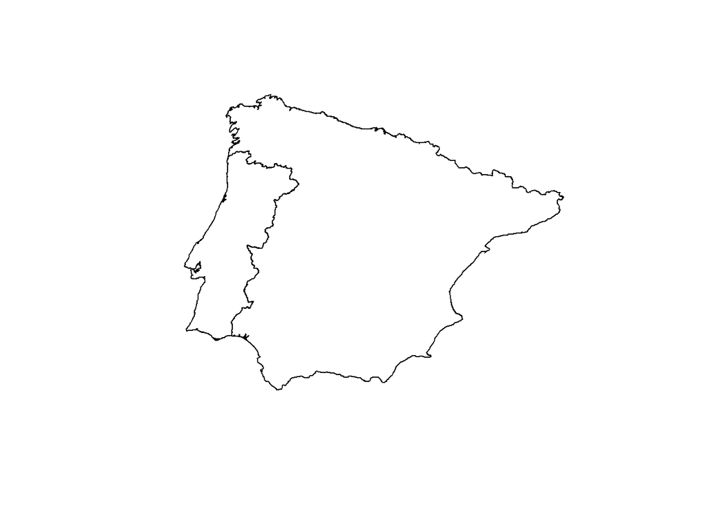

```r
penin_2 <- INLAcomp::polygon_IP
plot(penin_2)
```

## 2.2 We scale the covariates

```r
  #We scale the covariates
bio_scaled <- data %>%
  dplyr::select(starts_with("bio")) %>%
  scale(.)

colnames(bio_scaled) <- paste0("sc_", colnames(bio_scaled ))
data <- cbind(data, bio_scaled)
data[, c("x", "y", paste0("sc_bio", c(1, 2, 3, 4, 8, 12, 15, 18)))]
```

| x | y | sc_bio1 | sc_bio2 | sc_bio3 | sc_bio4 | sc_bio8 | sc_bio12 | sc_bio15 | sc_bio18 |
| --- | --- | --- | --- | --- | --- | --- | --- | --- | --- |
| 2905329 | 2016128 | 1.5026161432 | 0.8231379252 | 0.158060769 | 0.541711210 | 0.209274923 | -0.530575926 | 1.291924370 | -0.924087806 |
| 2845805 | 2201341 | 0.2707876120 | -0.0565737707 | 0.783862342 | -0.659767069 | -0.404334738 | 0.898970593 | 1.615364659 | -0.568866244 |
| 3434820 | 1811995 | 1.6017474629 | -0.7338121397 | 0.020413703 | -0.562782001 | 1.318492387 | 0.526621926 | -0.224480852 | 0.619453419 |
| 3371520 | 2095746 | -0.2671216806 | 0.4670641435 | -0.390567964 | 0.762380937 | 1.360973056 | -0.849885514 | -0.491226293 | -0.030458676 |
| 3036573 | 1889672 | 1.1987217694 | 0.4670641435 | -0.790475281 | 1.137242742 | -0.106970056 | -0.313760773 | 0.956767380 | -0.904972744 |
| 2941279 | 1807507 | 1.0362114091 | 0.5787735652 | -0.218449146 | 0.628583070 | -0.106970056 | -0.214491687 | 1.889510617 | -0.904972744 |
| 3227365 | 2237539 | -0.7107749643 | -0.7547576563 | -0.315737109 | -0.420994383 | -1.164266703 | -0.061108405 | -0.958115601 | 0.136798113 |
| 3606050 | 2186289 | -1.3396900587 | 0.5787735652 | 0.261800700 | 0.304337125 | 0.591600943 | -0.241727970 | -1.138055891 | 1.527418845 |
| 3459744 | 2062655 | 0.8460742875 | 0.0132446179 | -0.687246453 | 0.746699444 | 1.823540339 | -1.329387455 | -0.889280729 | -0.384087315 |
| 3033079 | 1995250 | 1.3222296432 | 0.7044466646 | -0.383857219 | 0.981945264 | -0.022008719 | -0.516241040 | 1.068005133 | -0.992583443 |

[output cut: 291 more lines]

## 2.3 Covariates raster

```r
bio1 <- raster("../rasters/bio1.tif")
bio12 <- raster("../rasters/bio12.tif")



#It has different resolution to the one that we want to predict. We aggregate it
#Aggregating to 10x10km
bio1 <- raster::aggregate(bio1, fact = 5, fun = "mean")
bio12 <- raster::aggregate(bio12, fact = 5, fun = "mean")

#Scaled it
str(bio_scaled)
```

```
#>  num [1:301, 1:8] 1.503 0.271 1.602 -0.267 1.199 ...
#>  - attr(*, "dimnames")=List of 2
#>   ..$ : NULL
#>   ..$ : chr [1:8] "sc_bio1" "sc_bio2" "sc_bio3" "sc_bio4" ...
#>  - attr(*, "scaled:center")= Named num [1:8] 12.339 11.834 0.407 6.185 8.744 ...
#>   ..- attr(*, "names")= chr [1:8] "bio1" "bio2" "bio3" "bio4" ...
#>  - attr(*, "scaled:scale")= Named num [1:8] 2.5639 1.1936 0.0248 0.7068 3.531 ...
#>   ..- attr(*, "names")= chr [1:8] "bio1" "bio2" "bio3" "bio4" ...
```

```r
attr(bio_scaled,"scaled:center")["bio12"]
```

```
#>    bio12
#> 754.5517
```

```r
attr(bio_scaled, "scaled:scale")["bio12"]
```

```
#>    bio12
#> 279.0395
```

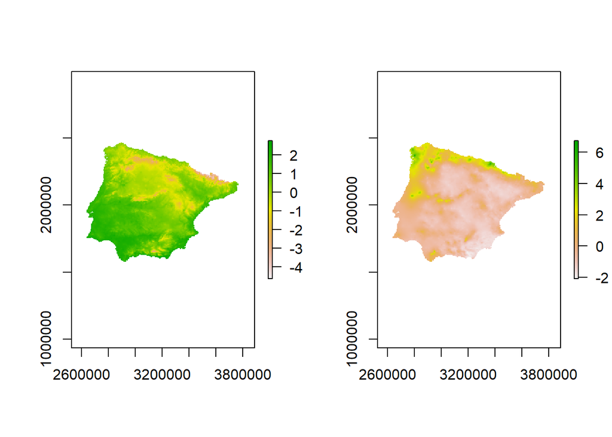

```r
# a <- (data$bio12 -attr(bio_scaled,"scaled:center")["bio12"])/attr(bio_scaled, "scaled:scale")["bio12"]
#
# round(a, 8) == round(bio_scaled[,"sc_bio12"],8)

sc_bio1 <- (bio1 - attr(bio_scaled,"scaled:center")["bio1"])/attr(bio_scaled,"scaled:scale")["bio1"]
sc_bio12 <- (bio12 - attr(bio_scaled,"scaled:center")["bio12"])/attr(bio_scaled,"scaled:scale")["bio12"]

par(mfrow=c(1,2))
plot(sc_bio1)
plot(sc_bio12)
```

## 2.4 Plotting the response

```r
penin_2_fort <- fortify(penin_2)
```

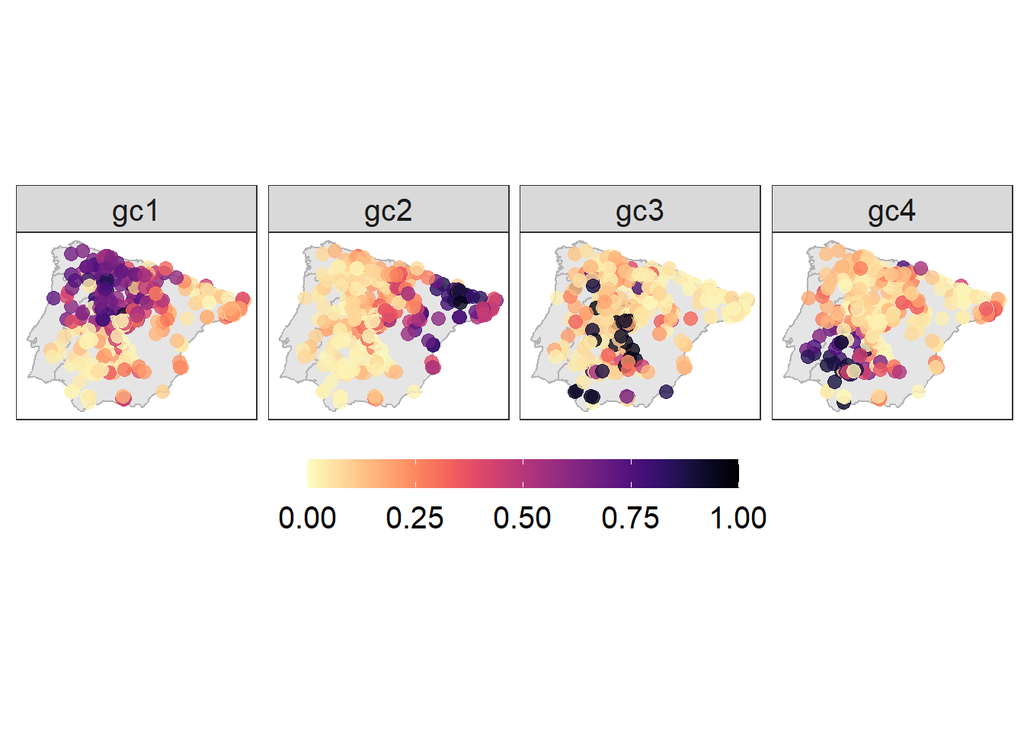

```r
data_plot <- data %>%
  dplyr::select(x, y, gc1, gc2, gc3, gc4) %>%
  tidyr::pivot_longer(all_of(paste0("gc", 1:4)))

p1 <- ggplot(data_plot) +
  geom_polygon(data = penin_2_fort, aes(x = long,
                                        y = lat,
                                        group = group),
               colour = 'gray70', fill = 'gray90')  +
  geom_point(data = data_plot,
             aes(x = x,
                 y = y,
                 #size = value,
                 color = value),
             alpha = 0.8, size = 3) +
  coord_fixed(ratio = 1) +
  facet_wrap(~ name, ncol = 4) +
  theme_bw() +
  theme(line = element_blank(),                          # remove axis lines ..
        axis.text = element_blank(),                       # .. tickmarks..
        axis.title = element_blank(),
        panel.background = element_blank(),
        legend.position = "bottom",
        legend.key.height = unit(0.5, "cm"),
        legend.key.width = unit(1.5, "cm"),
        legend.title = element_text(size = 17),
        legend.text = element_text(size = 15),
        strip.text = element_text(size = 15)) +
  #guides(fill = guide_legend(title.position="top", title.hjust = 0.5)) +
  xlab("") +
  ylab("") +
  scale_color_viridis(option="magma", direction = -1, limits = c(0, 1),
                      name = "")
print(p1)
```

## 2.5 `alr` transformation

We conduct the `alr`transformation, but, which category should be chosen as reference? The one with lowest variance. Also the one that has low variability. In this case, GC4.

```r
data %>% dplyr::select(gc1, gc2, gc3, gc4) %>%
  apply(., 2, function(x){var(log(x))})
```

```
#>      gc1      gc2      gc3      gc4
#> 1.658049 1.487854 1.392402 1.384200
```

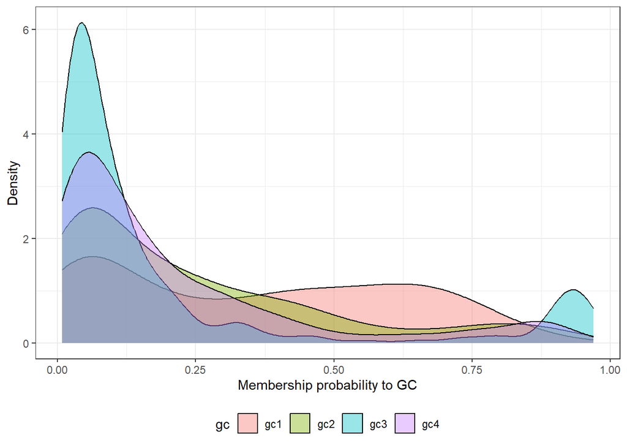

```r
#Also that they don't have so small values
data %>%
  tidyr::pivot_longer(., cols = all_of(paste0("gc", 1:4)),
                      names_to  = "gc",
                      values_to = "val_gc") %>%
  ggplot(data = .) +
  geom_density(aes(x = val_gc, fill = gc), alpha = 0.4) +
  theme_bw() +
  theme(legend.position = "bottom") +
  xlab("Membership probability to GC") +
  ylab("Density")
```

```r
### Reference category is gc4.
n <- dim(data)[1]
k <- 4
result_order <- c(paste0("gc", 1:k))
ref_cat <- paste0("gc", k)

names_gc <- c(result_order[!(result_order %in% ref_cat)])
result_order <- c(names_gc, ref_cat)


data <- cbind(data,
              alr = compositions::alr(data[, result_order]))

data[, c("x", "y", paste0("sc_bio", c(1, 2, 3, 4, 8, 12, 15, 18)), paste0("alr.gc", 1:3))]
```

| x | y | sc_bio1 | sc_bio2 | sc_bio3 | sc_bio4 | sc_bio8 | sc_bio12 | sc_bio15 | sc_bio18 | alr.gc1 | alr.gc2 | alr.gc3 |
| --- | --- | --- | --- | --- | --- | --- | --- | --- | --- | --- | --- | --- |
| 2905329 | 2016128 | 1.5026161432 | 0.8231379252 | 0.158060769 | 0.541711210 | 0.209274923 | -0.530575926 | 1.291924370 | -0.924087806 | -0.685634624 | -1.805256089 | -0.852688709 |
| 2845805 | 2201341 | 0.2707876120 | -0.0565737707 | 0.783862342 | -0.659767069 | -0.404334738 | 0.898970593 | 1.615364659 | -0.568866244 | 0.019357756 | -1.890066413 | -1.416673963 |
| 3434820 | 1811995 | 1.6017474629 | -0.7338121397 | 0.020413703 | -0.562782001 | 1.318492387 | 0.526621926 | -0.224480852 | 0.619453419 | -0.240455759 | 0.629184199 | -0.422447881 |
| 3371520 | 2095746 | -0.2671216806 | 0.4670641435 | -0.390567964 | 0.762380937 | 1.360973056 | -0.849885514 | -0.491226293 | -0.030458676 | 1.422662005 | 3.000043953 | 1.727495259 |
| 3036573 | 1889672 | 1.1987217694 | 0.4670641435 | -0.790475281 | 1.137242742 | -0.106970056 | -0.313760773 | 0.956767380 | -0.904972744 | -2.547608248 | -3.623638932 | -1.761823892 |
| 2941279 | 1807507 | 1.0362114091 | 0.5787735652 | -0.218449146 | 0.628583070 | -0.106970056 | -0.214491687 | 1.889510617 | -0.904972744 | -3.754932686 | -2.669676188 | -2.636615326 |
| 3227365 | 2237539 | -0.7107749643 | -0.7547576563 | -0.315737109 | -0.420994383 | -1.164266703 | -0.061108405 | -0.958115601 | 0.136798113 | 0.366030522 | 0.144889620 | -2.021827349 |
| 3606050 | 2186289 | -1.3396900587 | 0.5787735652 | 0.261800700 | 0.304337125 | 0.591600943 | -0.241727970 | -1.138055891 | 1.527418845 | 0.936935059 | 4.020299511 | 0.732249907 |
| 3459744 | 2062655 | 0.8460742875 | 0.0132446179 | -0.687246453 | 0.746699444 | 1.823540339 | -1.329387455 | -0.889280729 | -0.384087315 | 0.409597345 | 2.931607745 | 2.281558114 |
| 3033079 | 1995250 | 1.3222296432 | 0.7044466646 | -0.383857219 | 0.981945264 | -0.022008719 | -0.516241040 | 1.068005133 | -0.992583443 | -1.341653187 | -0.748246274 | -1.834525007 |

[output cut: 291 more lines]

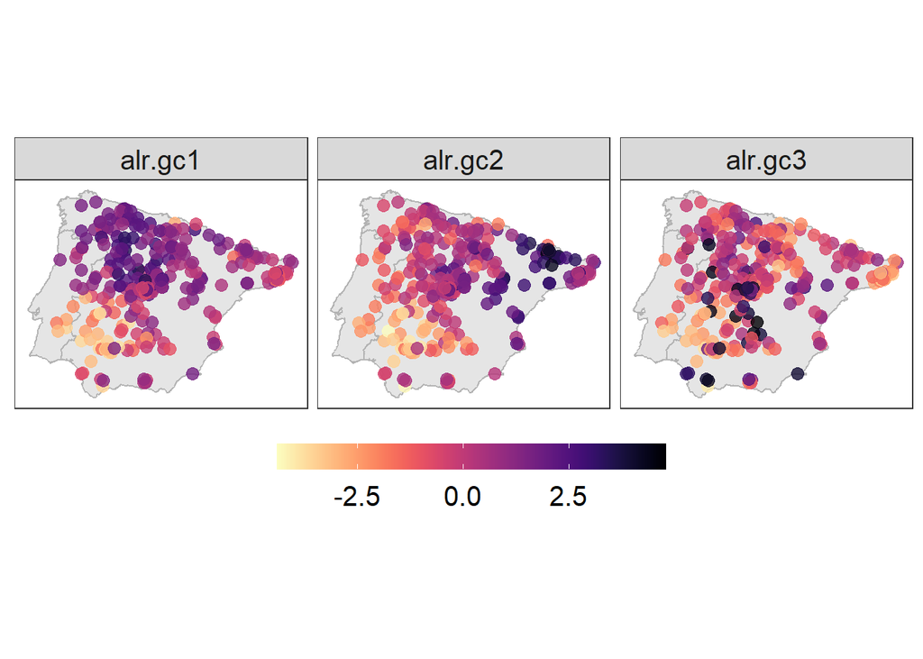

```r
### ----- 2.4. Descriptive map alr --- ####
data_plot_alr <- data %>%
  dplyr::select(all_of(c("x", "y", paste0("alr.", names_gc)))) %>%
  tidyr::pivot_longer(all_of(paste0("alr.", names_gc)))

#Plotting the map
p2 <- ggplot(data_plot_alr) +
  geom_polygon(data = penin_2_fort, aes(x = long,
                                        y = lat,
                                        group = group),
               colour = 'gray70', fill = 'gray90')  +
  geom_point(data = data_plot_alr,
             aes(x = x,
                 y = y,
                 #size = value,
                 color = value),
             alpha = 0.8, size = 3) +
  coord_fixed(ratio = 1) +
  facet_wrap(~ name) +
  theme_bw() +
  theme(line = element_blank(),                          # remove axis lines ..
        axis.text = element_blank(),                       # .. tickmarks..
        axis.title = element_blank(),
        panel.background = element_blank(),
        legend.position = "bottom",
        legend.key.height = unit(0.5, "cm"),
        legend.key.width = unit(1.5, "cm"),
        legend.title = element_text(size = 17),
        legend.text = element_text(size = 15),
        strip.text = element_text(size = 15)) +
  #guides(fill = guide_legend(title.position="top", title.hjust = 0.5)) +
  xlab("") +
  ylab("") +
  scale_color_viridis(option="magma", direction = -1,
                      name = "")

print(p2)
```

# 3 Preparing the data for fitting

## 3.1 Defining a new column with the values of all `alr` coordinates

```r
data_ext <- data %>%
  tidyr::pivot_longer(., cols = all_of(paste0("alr.", names_gc)),
                      names_to  = "alr_gc",
                      values_to = "val_alr_gc") %>%
  .[order(ordered(.$alr_gc)),]
head(data_ext[, c("x", "y", "alr_gc", "val_alr_gc")])
```

| x | y | alr_gc | val_alr_gc |
| --- | --- | --- | --- |
| 2905329 | 2016128 | alr.gc1 | -0.68563462 |
| 2845805 | 2201341 | alr.gc1 | 0.01935776 |
| 3434820 | 1811995 | alr.gc1 | -0.24045576 |
| 3371520 | 2095746 | alr.gc1 | 1.42266201 |
| 3036573 | 1889672 | alr.gc1 | -2.54760825 |
| 2941279 | 1807507 | alr.gc1 | -3.75493269 |

## 3.2 Defining index for indiciating which alr-coordinate are we dealing with

```r
data_ext$alr_gc <- ordered(data_ext$alr_gc)
k.group <- data_ext$alr_gc %>% as.numeric() #For group
k.repl  <- data_ext$alr_gc %>% as.numeric() #For replication
head(data.frame(k.group, k.repl))
```

|  | k.group | k.repl |
| --- | --- | --- |
| 1 | 1 | 1 |
| 2 | 1 | 1 |
| 3 | 1 | 1 |
| 4 | 1 | 1 |
| 5 | 1 | 1 |
| 6 | 1 | 1 |

## 3.3 The mesh

We create the mesh as we usually do in **R-INLA** for spatial effects.

```r
penin_inla <- inla.sp2segment(INLAcomp::polygon_IP_low)
mesh <- inla.mesh.2d(boundary = penin_inla,
                     max.edge = c(40000, 100000),
                     cutoff   = 30000,
                     min.angle= 30,
                     offset   = c(10000, 300000))
```

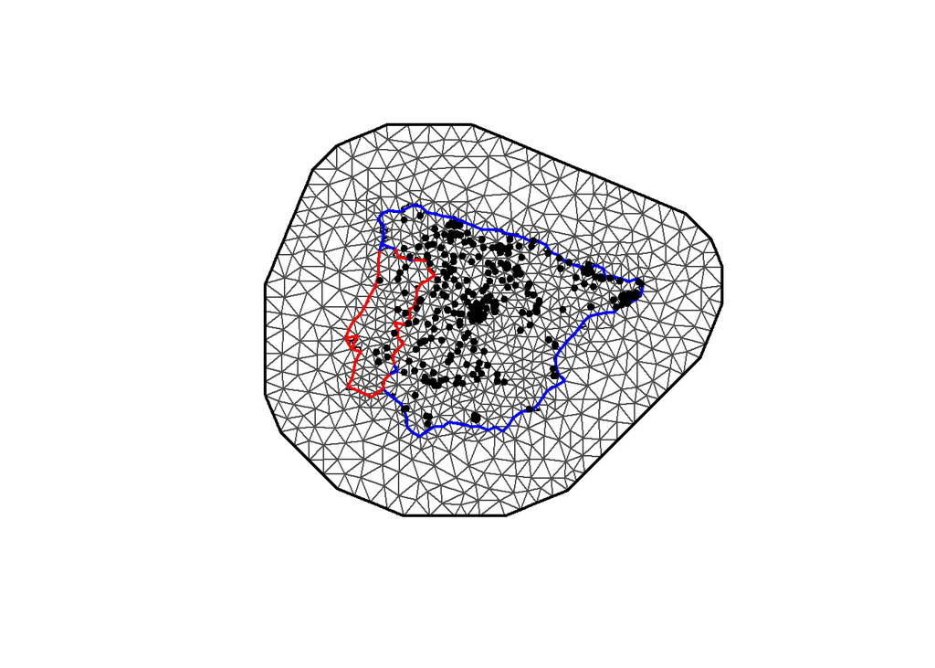

```r
plot(penin_2, xlim = c(mesh$loc[,1] %>% range()),
     ylim = c(mesh$loc[,2] %>% range(.)))
plot(mesh, add = TRUE)
points(data[,c("x", "y")], pch = 20)
```

## 3.4 Defining the spde

### 3.4.1 Defining spde with priors

We use PC-priors for defining the spde object.

```r
size <- min(c(diff(range(penin_inla$loc[,1])), diff(range(penin_inla$loc[,2]))))
range0 <- size / 4  # ~ default
spde <- inla.spde2.pcmatern(mesh        = mesh,
                            prior.range = c(range0, 0.25), # P(range < range0) = 0.25
                            prior.sigma = c(1, 0.01)) # P(sigma > 1) = 0.01
```

### 3.4.2 Index for the spatial effects

We distinguish if we copy the spatial effecto or we replicate it.

#### 3.4.2.1 Spatial index to be used in the model. We define it by alr-coordinate

This spatial index is useful when we replicate spatial effects, in other words, when we have one spatial effect per linear predictor whose realizations are different and hyperparameters are equal.

```r
iset <- inla.spde.make.index('i', n.spde = spde$n.spde,
                             n.repl  = k-1) #Replicating spatial effect
```

#### 3.4.2.2 This iset is for copy

This spatial index is useful when we copy spatial effects, in other words, when we have one spatial effect per linear predictor whose realizations are equal or proportionally equivalente, and hyperparameters are equal.

```r
iset2 <- inla.spde.make.index('i', n.spde = spde$n.spde)
iset_aux <- matrix(NA, ncol = k-1, nrow = k-1)
diag(iset_aux) <- rep(1, k-1)
iset2 <- kronecker(iset_aux, iset2$i)
colnames(iset2) <- paste0("iset.alr", 1:(k-1))
```

### 3.4.3 Defining the projection matrix

```r
A.est <- inla.spde.make.A(mesh  = mesh,
                          loc   = cbind(data_ext$x, data_ext$y),
                          repl  = k.repl)
A.est2 <- A.est
```

## 3.5 Defining the corresponding part to the shared random effect

### 3.5.1 Index for the random effect that is going to give the correlation

```r
id.z <- rep(1:(dim(data_ext)[1]/(k-1)), k-1)
id.z
```

```
#>   [1]   1   2   3   4   5   6   7   8   9  10  11  12  13  14  15  16
#>  [17]  17  18  19  20  21  22  23  24  25  26  27  28  29  30  31  32
#>  [33]  33  34  35  36  37  38  39  40  41  42  43  44  45  46  47  48
#>  [49]  49  50  51  52  53  54  55  56  57  58  59  60  61  62  63  64
#>  [65]  65  66  67  68  69  70  71  72  73  74  75  76  77  78  79  80
#>  [81]  81  82  83  84  85  86  87  88  89  90  91  92  93  94  95  96
#>  [97]  97  98  99 100 101 102 103 104 105 106 107 108 109 110 111 112
#> [113] 113 114 115 116 117 118 119 120 121 122 123 124 125 126 127 128
#> [129] 129 130 131 132 133 134 135 136 137 138 139 140 141 142 143 144
#> [145] 145 146 147 148 149 150 151 152 153 154 155 156 157 158 159 160
#> [161] 161 162 163 164 165 166 167 168 169 170 171 172 173 174 175 176
#> [177] 177 178 179 180 181 182 183 184 185 186 187 188 189 190 191 192
#> [193] 193 194 195 196 197 198 199 200 201 202 203 204 205 206 207 208
#> [209] 209 210 211 212 213 214 215 216 217 218 219 220 221 222 223 224
#> [225] 225 226 227 228 229 230 231 232 233 234 235 236 237 238 239 240
```

[output cut: 42 more lines]

### 3.5.2 Index for indicating the alr coordinate

```r
id.cat <- rep(1:(k-1), rep(n, k-1))
```

## 3.6 Defining the `inla.stack`

### 3.6.1 Response

We define a list with three elements (three alr-coordinates) in the format that **R-INLA** uses when deal with several likelihoods.

```r
#Response
names_alr <- paste0("alr.", names_gc)


1:length(names_alr) %>%
  lapply(., function(i){
    data_ext %>%
      dplyr::filter(alr_gc == names_alr[i]) -> data_comp_i
    #Response
    y_alr <- matrix(ncol = names_alr %>% length(.), nrow = dim(data_comp_i)[1])
    y_alr[, i] <- data_comp_i$val_alr_gc
  }) -> y_alr

1:length(names_alr) %>%
  lapply(., function(i){
    y_aux <- data_ext %>%
      dplyr::select(val_alr_gc, alr_gc) %>%
      dplyr::filter(alr_gc == names_alr[i]) %>%
      dplyr::select(val_alr_gc) %>%
      as.matrix(.)
    aux_vec <- rep(NA, k-1)
    aux_vec[i] <- 1
    kronecker(aux_vec, y_aux)
  }) -> y_alr_list

y_alr <- do.call(cbind, y_alr_list)
y_alr[1:10,]
```

```
#>              [,1] [,2] [,3]
#>  [1,] -0.68563462   NA   NA
#>  [2,]  0.01935776   NA   NA
#>  [3,] -0.24045576   NA   NA
#>  [4,]  1.42266201   NA   NA
#>  [5,] -2.54760825   NA   NA
#>  [6,] -3.75493269   NA   NA
#>  [7,]  0.36603052   NA   NA
#>  [8,]  0.93693506   NA   NA
#>  [9,]  0.40959735   NA   NA
#> [10,] -1.34165319   NA   NA
```

### 3.6.2 Covariates

Covariates are going to be included in the model as random effects with big variance. So, we need the values of the covariates (the scaled one), and also, an index indicating to which alr-coordinate it belongs.

```r
variables <- c("intercept", data %>%
                 dplyr::select(starts_with("sc_")) %>%
                 colnames(.))
id.names <- paste0("id.", variables)
id.variables <- rep(id.cat, length(variables)) %>%
  matrix(., ncol = length(variables), byrow = FALSE)
colnames(id.variables) <- id.names
```

### 3.6.3 Inla stack for estimation

```r
stk.est <- inla.stack(data    = list(resp = y_alr),
                      A       = list(A.est, 1, A.est2),
                      effects = list(c(iset),
                                     #list(intercept = 1)),
                                     cbind(data_ext %>%
                                             dplyr::select(starts_with("sc_bio")),
                                           #cbind(data_ext[,c(paste0("bio", c(1,2)))],
                                           id.z,
                                           id.variables,
                                           intercept = 1),
                                     data.frame(iset2)),
                      # data.frame(i.alr1 = iset,
                      #            i.alr2 = iset,
                      #            i.alr3 = iset)),
                      tag     = 'est')
```

# 4 Fitting the different models

## 4.1 Type I

Share the same parameters for fixed effects, and do not include spatial random e↵ects.

### 4.1.1 Fitting the model

```r
list_prior <- rep(list(list(prior = "pc.prec", param = c(1, 0.01))), k-1)

formula.typeI <- resp ~ -1 +
  intercept +
  sc_bio1 +
  sc_bio12 +
  f(id.z,
    model = "iid",
    hyper = list(prec = list(prior = "pc.prec",
                             param = c(1, 0.01))), constr = TRUE)

model.typeI <- inla(formula.typeI,
                   family         = rep("gaussian", k - 1),
                   data           = inla.stack.data(stk.est),
                   control.compute = list(config = TRUE,
                                          dic  = TRUE,
                                          waic = TRUE,
                                          cpo  = TRUE),
                   control.predictor = list(A = inla.stack.A(stk.est),
                                            compute = TRUE),
                   control.family = list_prior,
                   verbose = FALSE)
```

### 4.1.2 Posterior distribution of the fixed effects

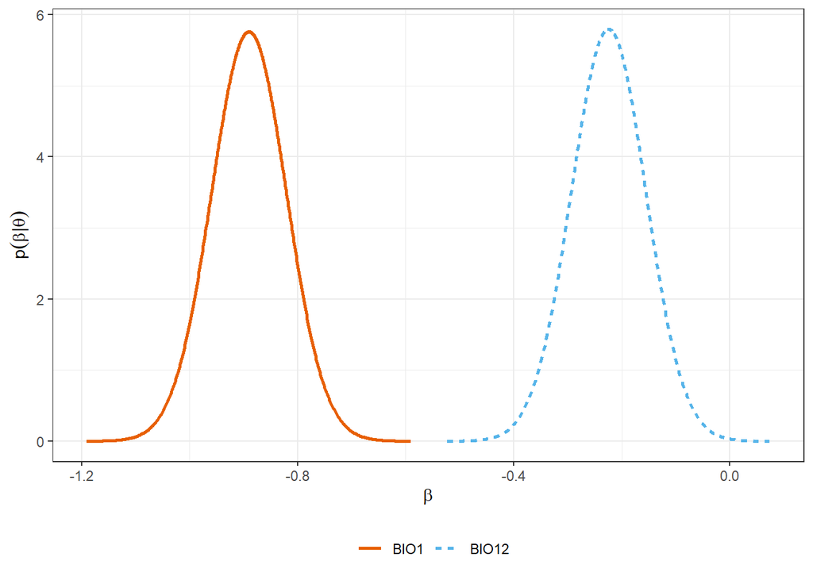

```r
data_fixed <- rbind(data.frame(inla.smarginal(model.typeI$marginals.fixed$sc_bio1), var = "BIO1"),
                    data.frame(inla.smarginal(model.typeI$marginals.fixed$sc_bio12), var = "BIO12"))

p_fixed <- ggplot() +
  geom_line(data = data_fixed, aes(x = x, y = y, col = var, linetype = var), size = 0.9) +
  #ggtitle("Effect of the covariate bio12") +
  theme_bw() +
  scale_color_manual(values=c("#E75F00", "#56B4E9"))+
  theme(legend.position = "bottom") +
  xlab(expression(beta)) +
  ylab(expression(p(beta *'|'* theta))) +
  theme(legend.title = element_blank())
p_fixed
```

### 4.1.3 Posterior distribution for the spatial effect

There is no spatial effect in this model

### 4.1.4 Posterior distribution of the hyperparameters

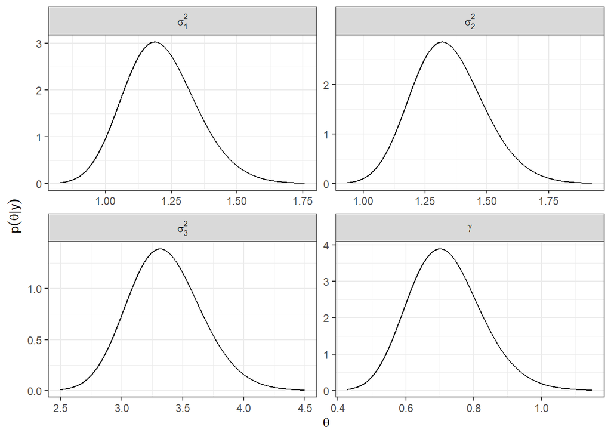

```r
### ------- 7.1.4. Posterior distributions of the hyperparameters --- ####
prec <- list(sigma2.1 = model.typeI$marginals.hyperpar$`Precision for the Gaussian observations`,
             sigma2.2 = model.typeI$marginals.hyperpar$`Precision for the Gaussian observations[2]`,
             sigma2.3 = model.typeI$marginals.hyperpar$`Precision for the Gaussian observations[3]`,
             gamma = model.typeI$marginals.hyper$`Precision for id.z`)

hyper <- lapply(1:length(prec),
                function(x){
                  inla.smarginal(inla.tmarginal(prec[[x]], fun = function(y)(1/y))) %>%
                    data.frame(.)
                })
names(hyper) <- names(prec)

hyper.df <- lapply(1:length(hyper),
                   function(x){
                     cbind(data.frame(hyper[[x]]), name1 = names(hyper)[x])
                   })  %>%
  do.call(rbind.data.frame, .)

hyper.df$name1 <- ordered(hyper.df$name1,
                          levels = c("sigma2.1", "sigma2.2", "sigma2.3",
                                     "gamma"))

hyper.df$name1 <- ordered(hyper.df$name1,
                          levels = c("sigma2.1", "sigma2.2", "sigma2.3", "gamma"),
                          labels = c("sigma[1]^2", "sigma[2]^2", "sigma[3]^2", "gamma"))

p.hyper <- ggplot(hyper.df) +
  geom_line(aes(x = x, y = y)) +
  facet_wrap(~ name1, scales = "free",              labeller = label_parsed) +
  theme_bw() +
  xlab(expression(theta)) +
  ylab(expression(p(theta*'|'*y)))

print(p.hyper)
```

## 4.2 Type II

Have different parameters for fixed effects, and do not include spatial random e↵ects.

### 4.2.1 Fitting the model

```r
formula.typeII <- resp ~ -1 +
  f(id.intercept, intercept,
    model   = "iid",
    initial = log(1/1000),
    fixed   = TRUE) +
  f(id.sc_bio1, sc_bio1, #BIO1
    model   = "iid",
    initial = log(1/1000),
    fixed   = TRUE) +
  f(id.sc_bio12, sc_bio12, #bio12
    model   = "iid",
    initial = log(1/1000),
    fixed   = TRUE) +
  f(id.z,
    model = "iid",
    hyper = list(prec = list(prior = "pc.prec",
                             param = c(1, 0.01))), constr = TRUE)

model.typeII <- inla(formula.typeII,
                   family         = rep("gaussian", k - 1),
                   data           = inla.stack.data(stk.est),
                   control.compute = list(config = TRUE,
                                          dic  = TRUE,
                                          waic = TRUE,
                                          cpo  = TRUE),
                   control.predictor = list(A = inla.stack.A(stk.est),
                                            compute = TRUE),
                   control.family = list_prior,
                   verbose = FALSE)
```

### 4.2.2 Posterior distribution of the fixed effects

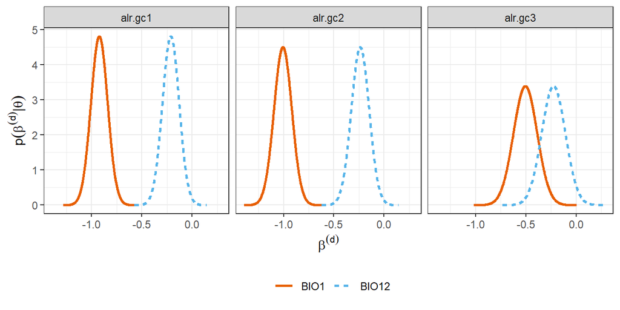

```r
data_fixed <- rbind(data.frame(inla.smarginal(model.typeII$marginals.random$id.sc_bio1$index.1), alr = "alr.gc1",
                               var = "BIO1"),
                    data.frame(inla.smarginal(model.typeII$marginals.random$id.sc_bio1$index.2), alr = "alr.gc2",
                               var = "BIO1"),
                    data.frame(inla.smarginal(model.typeII$marginals.random$id.sc_bio1$index.3), alr = "alr.gc3",
                               var = "BIO1"),
                    data.frame(inla.smarginal(model.typeII$marginals.random$id.sc_bio12$index.1), alr = "alr.gc1",
                               var = "BIO12"),
                    data.frame(inla.smarginal(model.typeII$marginals.random$id.sc_bio12$index.2), alr = "alr.gc2",
                               var = "BIO12"),
                    data.frame(inla.smarginal(model.typeII$marginals.random$id.sc_bio12$index.3), alr = "alr.gc3",
                               var = "BIO12"))
p_fixed <- ggplot() +
  geom_line(data = data_fixed, aes(x = x, y = y, col = var, linetype = var), size = 0.9) +
  #ggtitle("Effect of the covariate bio12") +
  theme_bw() +
  scale_color_manual(values=c("#E75F00", "#56B4E9"))+
  theme(legend.position = "bottom") +
  facet_wrap(~alr, nrow = 1) +
  xlab(expression(beta^(d))) +
  ylab(expression(p(beta^(d) *'|'* theta))) +
  theme(legend.title = element_blank())

p_fixed
```

### 4.2.3 Posterior distribution for the spatial effect

There is no spatial effects

### 4.2.4 Posterior distribution of the hyperparameters

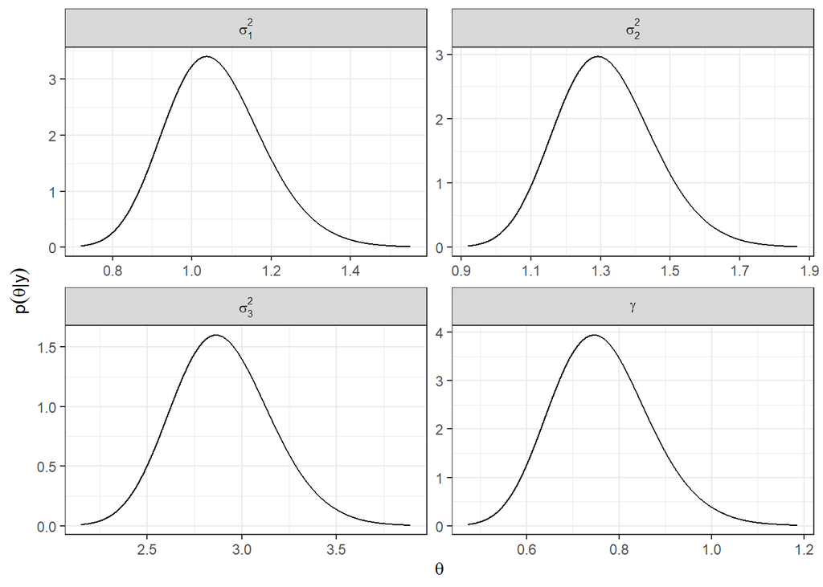

```r
prec <- list(sigma2.1 = model.typeII$marginals.hyperpar$`Precision for the Gaussian observations`,
             sigma2.2 = model.typeII$marginals.hyperpar$`Precision for the Gaussian observations[2]`,
             sigma2.3 = model.typeII$marginals.hyperpar$`Precision for the Gaussian observations[3]`,
             gamma = model.typeII$marginals.hyper$`Precision for id.z`)

hyper <- lapply(1:length(prec),
                function(x){
                  inla.smarginal(inla.tmarginal(prec[[x]], fun = function(y)(1/y))) %>%
                    data.frame(.)
                })
names(hyper) <- names(prec)
hyper.df <- lapply(1:length(hyper),
                   function(x){
                     cbind(data.frame(hyper[[x]]), name1 = names(hyper)[x])
                   })  %>%
  do.call(rbind.data.frame, .)

hyper.df$name1 <- ordered(hyper.df$name1,
                          levels = c("sigma2.1", "sigma2.2", "sigma2.3",
                                     "gamma", "phi", "sigma.sp"))

hyper.df$name1 <- ordered(hyper.df$name1,
                          levels = c("sigma2.1", "sigma2.2", "sigma2.3", "gamma", "phi", "sigma.sp"),
                          labels = c("sigma[1]^2", "sigma[2]^2", "sigma[3]^2", "gamma", "phi", "sigma[w]"))

p.hyper <- ggplot(hyper.df) +
  geom_line(aes(x = x, y = y)) +
  facet_wrap(~ name1, scales = "free",              labeller = label_parsed) +
  theme_bw() +
  xlab(expression(theta)) +
  ylab(expression(p(theta*'|'*y)))

print(p.hyper)
```

## 4.3 Type III

Share the same parameters for fixed effects, and share the same spatial effect.

### 4.3.1 Fitting the model

```r
formula.typeIII <- resp ~ -1 +
  intercept +
  sc_bio1 +
  sc_bio12 +
  f(iset.alr1, model = spde) +
  f(iset.alr2, copy = "iset.alr1",
    fixed = TRUE) +
  f(iset.alr3, copy = "iset.alr1",
    fixed = TRUE) +
  f(id.z,
    model = "iid",
    hyper = list(prec = list(prior = "pc.prec",
                             param = c(1, 0.01))), constr = TRUE)

model.typeIII <- inla(formula.typeIII,
                   family         = rep("gaussian", k - 1),
                   data           = inla.stack.data(stk.est),
                   control.compute = list(config = TRUE,
                                          dic  = TRUE,
                                          waic = TRUE,
                                          cpo  = TRUE),
                   control.predictor = list(A = inla.stack.A(stk.est),
                                            compute = TRUE),
                   control.family = list_prior,
                   verbose = FALSE)
```

### 4.3.2 Posterior distribution of the fixed effects

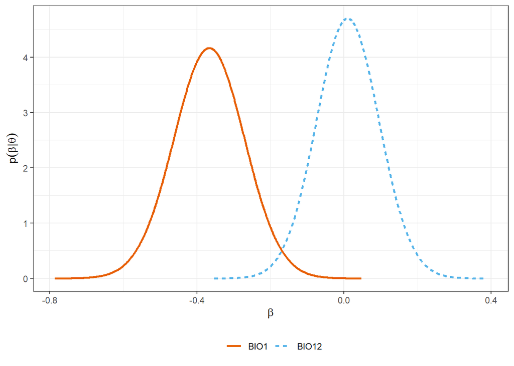

```r
data_fixed <- rbind(#data.frame(inla.smarginal(model.typeI$marginals.fixed$intercept), var = "Intercept"),
                    data.frame(inla.smarginal(model.typeIII$marginals.fixed$sc_bio1), var = "BIO1"),
                    data.frame(inla.smarginal(model.typeIII$marginals.fixed$sc_bio12), var = "BIO12"))

p_fixed <- ggplot() +
  geom_line(data = data_fixed, aes(x = x, y = y, col = var, linetype = var), size = 0.9) +
  #ggtitle("Effect of the covariate bio12") +
  theme_bw() +
  scale_color_manual(values=c("#E75F00", "#56B4E9"))+
  theme(legend.position = "bottom") +
  xlab(expression(beta)) +
  ylab(expression(p(beta *'|'* theta))) +
  theme(legend.title = element_blank())

p_fixed
```

### 4.3.3 Posterior distribution for the spatial effect

```r
raster_predict <- INLAcomp::raster_predict

spatial_mean <- lapply(paste0("iset.alr", 1:3), function(a){
  raster_spatial_effect(spatial = model.typeIII$summary.random[[c(a)]][['mean']],
                                      boundary = raster_predict)
})


spatial_sd <- lapply(paste0("iset.alr", 1:3), function(a){
  raster_spatial_effect(spatial = model.typeIII$summary.random[[a]]$sd,
                                    boundary = raster_predict)
})
```

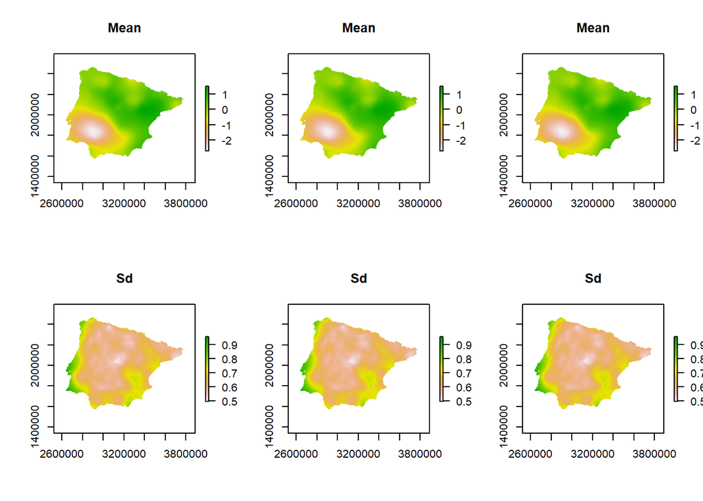

```r
par(mfrow = c(2,3))
plot(spatial_mean[[1]], main = "Mean")
plot(spatial_mean[[2]], main = "Mean")
plot(spatial_mean[[3]], main = "Mean")

plot(spatial_sd[[1]], main = "Sd")
plot(spatial_sd[[2]], main = "Sd")
plot(spatial_sd[[3]], main = "Sd")
```

### 4.3.4 Posterior distribution of the hyperparameters

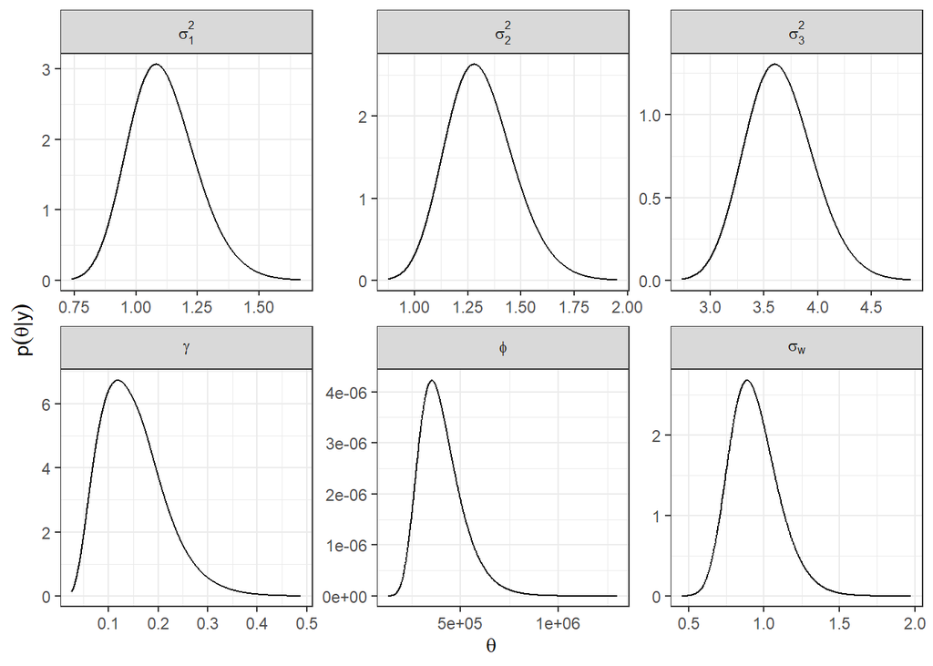

```r
prec <- list(sigma2.1 = model.typeIII$marginals.hyperpar$`Precision for the Gaussian observations`,
             sigma2.2 = model.typeIII$marginals.hyperpar$`Precision for the Gaussian observations[2]`,
             sigma2.3 = model.typeIII$marginals.hyperpar$`Precision for the Gaussian observations[3]`,
             gamma = model.typeIII$marginals.hyper$`Precision for id.z`)

hyper <- lapply(1:length(prec),
                function(x){
                  inla.smarginal(inla.tmarginal(prec[[x]], fun = function(y)(1/y))) %>%
                    data.frame(.)
                })
names(hyper) <- names(prec)
hyper <- c(hyper,
           sigma.sp = list(inla.smarginal(model.typeIII$marginals.hyperpar[["Stdev for iset.alr1"]])),
           phi = list(inla.smarginal(model.typeIII$marginals.hyperpar[["Range for iset.alr1"]])))
hyper.df <- lapply(1:length(hyper),
                   function(x){
                     cbind(data.frame(hyper[[x]]), name1 = names(hyper)[x])
                   })  %>%
  do.call(rbind.data.frame, .)

hyper.df$name1 <- ordered(hyper.df$name1,
                          levels = c("sigma2.1", "sigma2.2", "sigma2.3",
                                     "gamma", "phi", "sigma.sp"))


hyper.df$name1 <- ordered(hyper.df$name1,
                          levels = c("sigma2.1", "sigma2.2", "sigma2.3", "gamma", "phi", "sigma.sp"),
                          labels = c("sigma[1]^2", "sigma[2]^2", "sigma[3]^2", "gamma", "phi", "sigma[w]"))


p.hyper <- ggplot(hyper.df) +
  geom_line(aes(x = x, y = y)) +
  facet_wrap(~ name1, scales = "free",              labeller = label_parsed) +
  theme_bw() +
  xlab(expression(theta)) +
  ylab(expression(p(theta*'|'*y)))

print(p.hyper)
```

## 4.4 Type IV

Have different parameters for fixed effects, and share the same spatial effect.

### 4.4.1 Fitting the model

```r
list_prior <- rep(list(list(prior = "pc.prec", param = c(1, 0.01))), k-1)

formula.typeIV <- resp ~ -1 +
  f(id.intercept, intercept,
    model   = "iid",
    initial = log(1/1000),
    fixed   = TRUE) +
  f(id.sc_bio1, sc_bio1, #BIO1
    model   = "iid",
    initial = log(1/1000),
    fixed   = TRUE) +
  f(id.sc_bio12, sc_bio12, #bio12
    model   = "iid",
    initial = log(1/1000),
    fixed   = TRUE) +
  f(iset.alr1, model = spde) +
  f(iset.alr2, copy = "iset.alr1",
    fixed = TRUE) +
  f(iset.alr3, copy = "iset.alr1",
    fixed = TRUE) +
  f(id.z,
    model = "iid",
    hyper = list(prec = list(prior = "pc.prec",
                             param = c(1, 0.01))),
    constr = TRUE)

model.typeIV <- inla(formula.typeIV,
                   family         = rep("gaussian", k - 1),
                   data           = inla.stack.data(stk.est),
                   control.compute = list(config = TRUE,
                                          dic  = TRUE,
                                          waic = TRUE,
                                          cpo  = TRUE),
                   control.predictor = list(A = inla.stack.A(stk.est),
                                            compute = TRUE),
                   control.family = list_prior,
                   verbose = FALSE)
```

### 4.4.2 Posterior distribution of the fixed effects

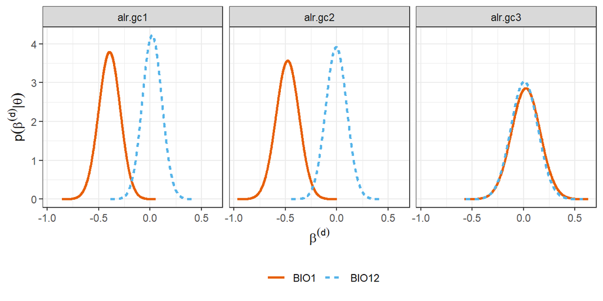

```r
##Bio12
data_fixed <- rbind(data.frame(inla.smarginal(model.typeIV$marginals.random$id.sc_bio1$index.1), alr = "alr.gc1",
                               var = "BIO1"),
                    data.frame(inla.smarginal(model.typeIV$marginals.random$id.sc_bio1$index.2), alr = "alr.gc2",
                               var = "BIO1"),
                    data.frame(inla.smarginal(model.typeIV$marginals.random$id.sc_bio1$index.3), alr = "alr.gc3",
                               var = "BIO1"),
                    data.frame(inla.smarginal(model.typeIV$marginals.random$id.sc_bio12$index.1), alr = "alr.gc1",
                               var = "BIO12"),
                    data.frame(inla.smarginal(model.typeIV$marginals.random$id.sc_bio12$index.2), alr = "alr.gc2",
                               var = "BIO12"),
                    data.frame(inla.smarginal(model.typeIV$marginals.random$id.sc_bio12$index.3), alr = "alr.gc3",
                               var = "BIO12"))
p_fixed <- ggplot() +
  geom_line(data = data_fixed, aes(x = x, y = y, col = var, linetype = var), size = 0.9) +
  #ggtitle("Effect of the covariate bio12") +
  theme_bw() +
  scale_color_manual(values=c("#E75F00", "#56B4E9"))+
  theme(legend.position = "bottom") +
  facet_wrap(~alr, nrow = 1) +
  xlab(expression(beta^(d))) +
  ylab(expression(p(beta^(d) *'|'* theta))) +
  theme(legend.title = element_blank())

p_fixed
```

### 4.4.3 Posterior distribution for the spatial effect

```r
raster_predict <- INLAcomp::raster_predict

spatial_mean <- lapply(paste0("iset.alr", 1:3), function(a){
  raster_spatial_effect(spatial = model.typeIV$summary.random[[c(a)]][['mean']],
                                      boundary = raster_predict)
})


spatial_sd <- lapply(paste0("iset.alr", 1:3), function(a){
  raster_spatial_effect(spatial = model.typeIV$summary.random[[a]]$sd,
                                    boundary = raster_predict)
})
```

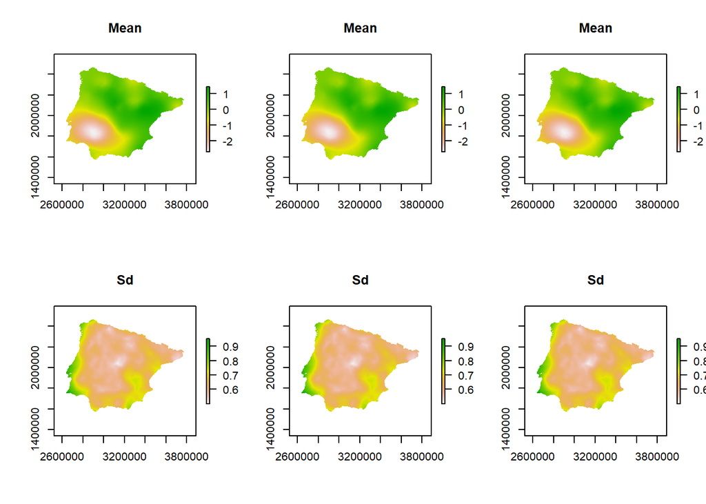

```r
par(mfrow = c(2,3))
plot(spatial_mean[[1]], main = "Mean")
plot(spatial_mean[[2]], main = "Mean")
plot(spatial_mean[[3]], main = "Mean")

plot(spatial_sd[[1]], main = "Sd")
plot(spatial_sd[[2]], main = "Sd")
plot(spatial_sd[[3]], main = "Sd")
```

### 4.4.4 Posterior distribution of the hyperparameters

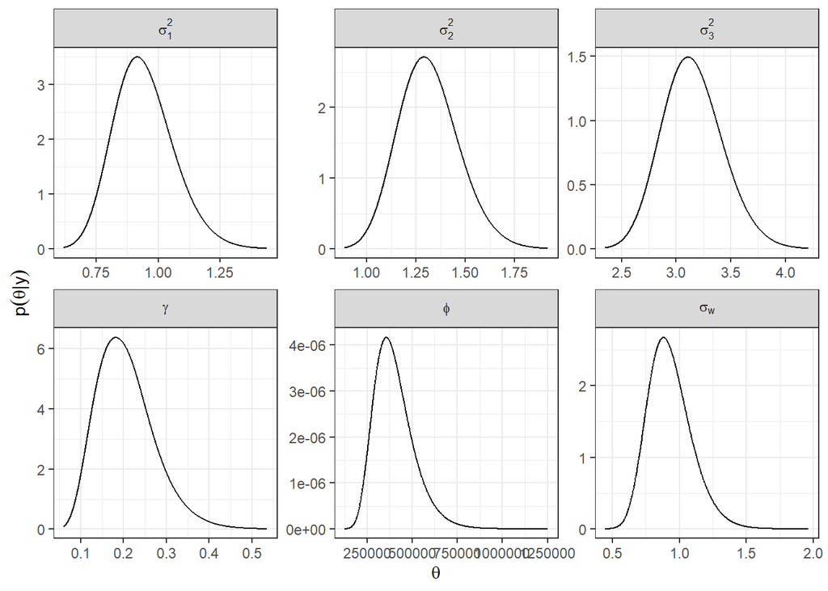

```r
### ------- 7.1.4. Posterior distributions of the hyperparameters --- ####
prec <- list(sigma2.1 = model.typeIV$marginals.hyperpar$`Precision for the Gaussian observations`,
             sigma2.2 = model.typeIV$marginals.hyperpar$`Precision for the Gaussian observations[2]`,
             sigma2.3 = model.typeIV$marginals.hyperpar$`Precision for the Gaussian observations[3]`,
             gamma = model.typeIV$marginals.hyperpar$`Precision for id.z`)


hyper <- lapply(1:length(prec),
                function(x){
                  inla.smarginal(inla.tmarginal(prec[[x]], fun = function(y)(1/y))) %>%
                    data.frame(.)
                })

names(hyper) <- names(prec)
hyper <- c(hyper,
           sigma.sp = list(inla.smarginal(model.typeIV$marginals.hyperpar[["Stdev for iset.alr1"]])),
           phi = list(inla.smarginal(model.typeIV$marginals.hyperpar[["Range for iset.alr1"]])))
hyper.df <- lapply(1:length(hyper),
                   function(x){
                     cbind(data.frame(hyper[[x]]), name1 = names(hyper)[x])
                   })  %>%
  do.call(rbind.data.frame, .)

hyper.df$name1 <- ordered(hyper.df$name1,
                          levels = c("sigma2.1", "sigma2.2", "sigma2.3",
                                     "gamma", "phi", "sigma.sp"))

hyper.df$name1 <- ordered(hyper.df$name1,
                          levels = c("sigma2.1", "sigma2.2", "sigma2.3", "gamma", "phi", "sigma.sp"),
                          labels = c("sigma[1]^2", "sigma[2]^2", "sigma[3]^2", "gamma", "phi", "sigma[w]"))

p.hyper <- ggplot(hyper.df) +
  geom_line(aes(x = x, y = y)) +
  facet_wrap(~ name1, scales = "free",              labeller = label_parsed) +
  theme_bw() +
  xlab(expression(theta)) +
  ylab(expression(p(theta*'|'*y)))

print(p.hyper)
```

## 4.5 Type V

Share the same parameters for fixed effects, and the spatial effects between linear predictors are proportional.

### 4.5.1 Fitting the model

```r
formula.typeV <- resp ~ -1 +
  intercept +
  sc_bio1 +
  sc_bio12 +
  f(iset.alr1, model = spde) +
  f(iset.alr2, copy = "iset.alr1",
    fixed = FALSE) +
  f(iset.alr3, copy = "iset.alr1",
    fixed = FALSE) +
  f(id.z,
    model = "iid",
    hyper = list(prec = list(prior = "pc.prec",
                             param = c(1, 0.01))), constr = TRUE)

model.typeV <- inla(formula.typeV,
                   family         = rep("gaussian", k - 1),
                   data           = inla.stack.data(stk.est),
                   control.compute = list(config = TRUE,
                                          dic  = TRUE,
                                          waic = TRUE,
                                          cpo  = TRUE),
                   control.predictor = list(A = inla.stack.A(stk.est),
                                            compute = TRUE),
                   control.family = list_prior,
                   verbose = FALSE)
```

### 4.5.2 Posterior distribution of the fixed effects

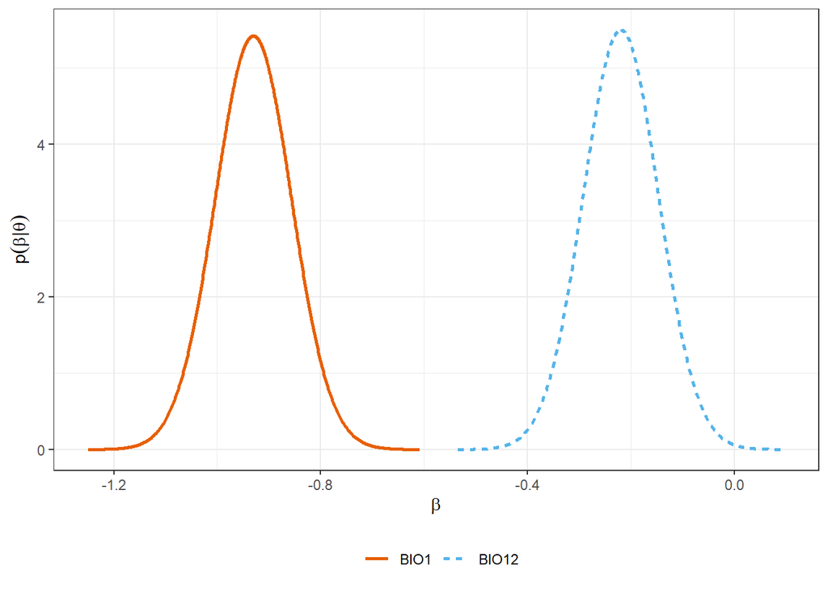

```r
data_fixed <- rbind(#data.frame(inla.smarginal(model.typeI$marginals.fixed$intercept), var = "Intercept"),
                    data.frame(inla.smarginal(model.typeV$marginals.fixed$sc_bio1), var = "BIO1"),
                    data.frame(inla.smarginal(model.typeV$marginals.fixed$sc_bio12), var = "BIO12"))

p_fixed <- ggplot() +
  geom_line(data = data_fixed, aes(x = x, y = y, col = var, linetype = var), size = 0.9) +
  #ggtitle("Effect of the covariate bio12") +
  theme_bw() +
  scale_color_manual(values=c("#E75F00", "#56B4E9"))+
  theme(legend.position = "bottom") +
  xlab(expression(beta)) +
  ylab(expression(p(beta *'|'* theta))) +
  theme(legend.title = element_blank())

p_fixed
```

### 4.5.3 Posterior distribution for the spatial effect

```r
raster_predict <- INLAcomp::raster_predict

spatial_mean <- lapply(paste0("iset.alr", 1:3), function(a){
  raster_spatial_effect(spatial = model.typeV$summary.random[[c(a)]][['mean']],
                                      boundary = raster_predict)
})


spatial_sd <- lapply(paste0("iset.alr", 1:3), function(a){
  raster_spatial_effect(spatial = model.typeV$summary.random[[a]]$sd,
                                    boundary = raster_predict)
})
```

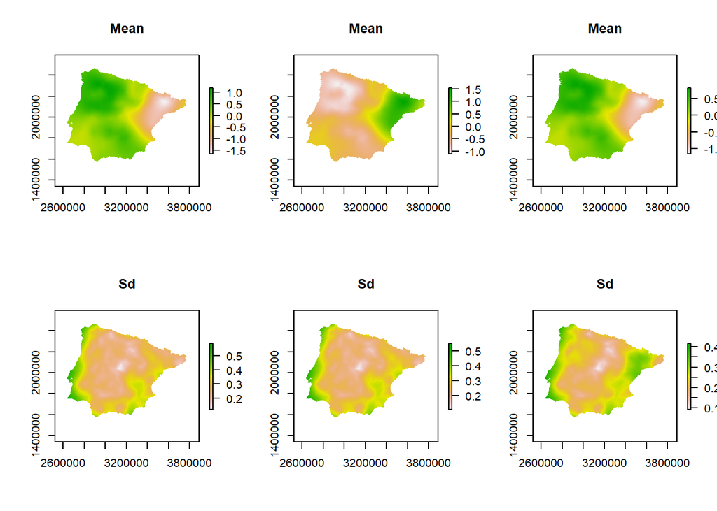

```r
par(mfrow = c(2,3))
plot(spatial_mean[[1]], main = "Mean")
plot(spatial_mean[[2]], main = "Mean")
plot(spatial_mean[[3]], main = "Mean")

plot(spatial_sd[[1]], main = "Sd")
plot(spatial_sd[[2]], main = "Sd")
plot(spatial_sd[[3]], main = "Sd")
```

### 4.5.4 Posterior distribution of the hyperparameters

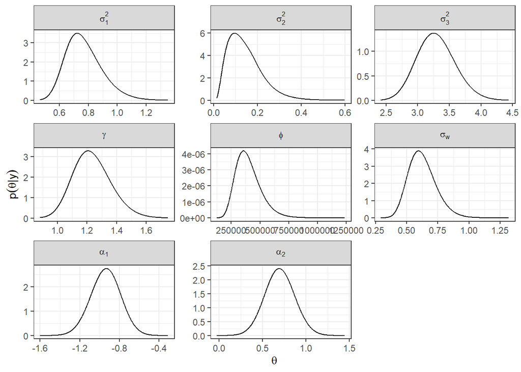

```r
### ------- 7.1.4. Posterior distributions of the hyperparameters --- ####
prec <- list(sigma2.1 = model.typeV$marginals.hyperpar$`Precision for the Gaussian observations`,
             sigma2.2 = model.typeV$marginals.hyperpar$`Precision for the Gaussian observations[2]`,
             sigma2.3 = model.typeV$marginals.hyperpar$`Precision for the Gaussian observations[3]`,
             gamma = model.typeV$marginals.hyper$`Precision for id.z`)

hyper <- lapply(1:length(prec),
                function(x){
                  inla.smarginal(inla.tmarginal(prec[[x]], fun = function(y)(1/y))) %>%
                    data.frame(.)
                })
names(hyper) <- names(prec)
hyper <- c(hyper,
           sigma.sp = list(inla.smarginal(model.typeV$marginals.hyperpar[["Stdev for iset.alr1"]])),
           phi = list(inla.smarginal(model.typeV$marginals.hyperpar[["Range for iset.alr1"]])),
           alpha1 = list(inla.smarginal(model.typeV$marginals.hyperpar[["Beta for iset.alr2"]])),
           alpha2 = list(inla.smarginal(model.typeV$marginals.hyperpar[["Beta for iset.alr3"]])))




hyper.df <- lapply(1:length(hyper),
                   function(x){
                     cbind(data.frame(hyper[[x]]), name1 = names(hyper)[x])
                   })  %>%
  do.call(rbind.data.frame, .)

hyper.df$name1 <- ordered(hyper.df$name1,
                          levels = c("sigma2.1", "sigma2.2", "sigma2.3",
                                     "gamma", "phi", "sigma.sp", "alpha1", "alpha2"))

hyper.df$name1 <- ordered(hyper.df$name1,
                          levels = c("sigma2.1", "sigma2.2", "sigma2.3", "gamma", "phi", "sigma.sp", "alpha1", "alpha2"),
                          labels = c("sigma[1]^2", "sigma[2]^2", "sigma[3]^2", "gamma", "phi", "sigma[w]", "alpha[1]", "alpha[2]"))

p.hyper <- ggplot(hyper.df) +
  geom_line(aes(x = x, y = y)) +
  facet_wrap(~ name1, scales = "free",              labeller = label_parsed) +
  theme_bw() +
  xlab(expression(theta)) +
  ylab(expression(p(theta*'|'*y)))

print(p.hyper)
```

## 4.6 Type VI

Have different parameters for fixed effects, and the spatial effects between linear predictors are proportional

### 4.6.1 Fitting the model

```r
list_prior <- rep(list(list(prior = "pc.prec", param = c(1, 0.01))), k-1)

formula.typeVI <- resp ~ -1 +
 #intercept +
    f(id.intercept, intercept,
    model   = "iid",
    initial = log(1/1000),
    fixed   = TRUE,
    constr = TRUE) +
  f(id.sc_bio1, sc_bio1, #bio1
    model   = "iid",
    initial = log(1/1000),
    fixed   = TRUE) +
  f(id.sc_bio12, sc_bio12, #bio12
    model   = "iid",
    initial = log(1/1000),
    fixed   = TRUE) +
  f(iset.alr1, model = spde) +
  f(iset.alr2, copy = "iset.alr1",
    hyper = list(beta = list(fixed = FALSE, params = c(0, 1)))) +
  f(iset.alr3, copy = "iset.alr1",
         hyper = list(beta = list(fixed = FALSE, params = c(0, 1)))) +
  f(id.z,
    model = "iid",
    hyper = list(prec = list(prior = "pc.prec",
                             param = c(1, 0.01))),
    constr = TRUE)

# stk.est$A %>% dim(.)
# stk.est$effects$data$id.intercept %>% table(.)
# int1 <- int2 <- int3 <- stk.est$effects$data$id.intercept
#
# int1[which(int1!= 1)] <- NA
# int2[which(int1!= 2)] <- NA
# int3[which(int1!= 3)] <- NA
# A <- matrix(stk.est$effects$data$sc_bio8)
#
# A <- matrix(data$sc_bio8, ncol = 1)


#
# A.int <- matrix(rep(1, 301), ncol = 1)
#
# e <- rep(0, 1)
# dim(A.int)

model.typeVI <- inla(formula.typeVI,
                   family         = rep("gaussian", k - 1),
                   data           = inla.stack.data(stk.est),
                   control.compute = list(config = TRUE,
                                          dic  = TRUE,
                                          waic = TRUE,
                                          cpo  = TRUE),
                   control.predictor = list(A = inla.stack.A(stk.est),
                                            compute = TRUE),
                   control.family = list_prior,
                   verbose = FALSE)

model.typeVI <- inla.rerun(model.typeVI)
summary(model.typeVI)
```

```
#>
#> Call:
#>    c("inla.core(formula = formula, family = family, contrasts =
#>    contrasts, ", " data = data, quantiles = quantiles, E = E,
#>    offset = offset, ", " scale = scale, weights = weights,
#>    Ntrials = Ntrials, strata = strata, ", " lp.scale = lp.scale,
#>    link.covariates = link.covariates, verbose = verbose, ", "
#>    lincomb = lincomb, selection = selection, control.compute =
#>    control.compute, ", " control.predictor = control.predictor,
#>    control.family = control.family, ", " control.inla =
#>    control.inla, control.fixed = control.fixed, ", " control.mode
#>    = control.mode, control.expert = control.expert, ", "
#>    control.hazard = control.hazard, control.lincomb =
#>    control.lincomb, ", " control.update = control.update,
#>    control.lp.scale = control.lp.scale, ", " control.pardiso =
#>    control.pardiso, only.hyperparam = only.hyperparam, ", "
#>    inla.call = inla.call, inla.arg = inla.arg, num.threads =
#>    num.threads, ", " keep = keep, working.directory =
#>    working.directory, silent = silent, ", " inla.mode =
#>    inla.mode, safe = FALSE, debug = debug, .parent.frame =
#>    .parent.frame)" )
#> Time used:
#>     Pre = 3.31, Running = 13.5, Post = 1.07, Total = 17.9
#> Random effects:
#>   Name     Model
#>     id.intercept IID model
#>    id.sc_bio1 IID model
#>    id.sc_bio12 IID model
#>    iset.alr1 SPDE2 model
#>    id.z IID model
#>    iset.alr2 Copy
#>    iset.alr3 Copy
#>
#> Model hyperparameters:
#>                                                 mean       sd
#> Precision for the Gaussian observations     1.27e+00 1.88e-01
#> Precision for the Gaussian observations[2]  1.05e+01 7.39e+00
#> Precision for the Gaussian observations[3]  3.85e-01 3.60e-02
#> Range for iset.alr1                         4.77e+05 1.37e+05
#> Stdev for iset.alr1                         6.78e-01 1.24e-01
```

[output cut: 18 more lines]

```
#> Precision for id.z                           9.81e-01  8.02e-01
#> Beta for iset.alr2                          -6.57e-01 -9.25e-01
#> Beta for iset.alr3                           1.26e+00  9.46e-01
#>
#> Deviance Information Criterion (DIC) ...............: 2498.21
#> Deviance Information Criterion (DIC, saturated) ....: 1220.12
#> Effective number of parameters .....................: 306.40
#>
#> Watanabe-Akaike information criterion (WAIC) ...: 2506.81
#> Effective number of parameters .................: 251.19
#>
#> Marginal log-Likelihood:  -1602.11
#> CPO, PIT is computed
#> Posterior summaries for the linear predictor and the fitted values are computed
#> (Posterior marginals needs also 'control.compute=list(return.marginals.predictor=TRUE)')
```

```r
-mean(log(model.typeVI$cpo$cpo))
```

```
#> [1] 1.523604
```

### 4.6.2 Posterior distribution of the fixed effects

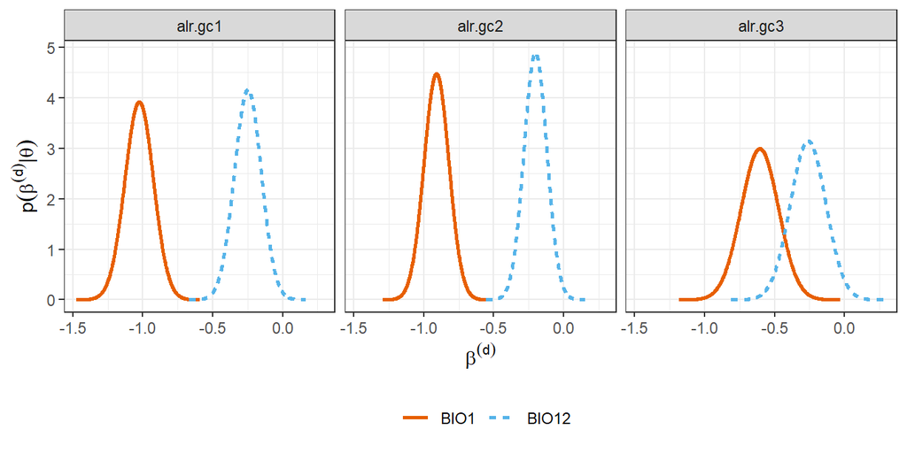

```r
  ### ----- 7.1. Posterior distributions of fixed effects and hyperpars --- ####
### ------- 7.1.1. Fixed effects --- ####
##Bio12
data_fixed <- rbind(data.frame(inla.smarginal(model.typeVI$marginals.random$id.sc_bio1$index.1), alr = "alr.gc1",
                               var = "BIO1"),
                    data.frame(inla.smarginal(model.typeVI$marginals.random$id.sc_bio1$index.2), alr = "alr.gc2",
                               var = "BIO1"),
                    data.frame(inla.smarginal(model.typeVI$marginals.random$id.sc_bio1$index.3), alr = "alr.gc3",
                               var = "BIO1"),
                    data.frame(inla.smarginal(model.typeVI$marginals.random$id.sc_bio12$index.1), alr = "alr.gc1",
                               var = "BIO12"),
                    data.frame(inla.smarginal(model.typeVI$marginals.random$id.sc_bio12$index.2), alr = "alr.gc2",
                               var = "BIO12"),
                    data.frame(inla.smarginal(model.typeVI$marginals.random$id.sc_bio12$index.3), alr = "alr.gc3",
                               var = "BIO12"))
p_fixed <- ggplot() +
  geom_line(data = data_fixed, aes(x = x, y = y, col = var, linetype = var), size = 0.9) +
  #ggtitle("Effect of the covariate bio12") +
  theme_bw() +
  scale_color_manual(values=c("#E75F00", "#56B4E9"))+
  theme(legend.position = "bottom") +
  facet_wrap(~alr, nrow = 1) +
  xlab(expression(beta^(d))) +
  ylab(expression(p(beta^(d) *'|'* theta))) +
  theme(legend.title = element_blank())

p_fixed
```

### 4.6.3 Posterior distribution for the spatial effect

```r
raster_predict <- INLAcomp::raster_predict

spatial_mean <- lapply(paste0("iset.alr", 1:3), function(a){
  raster_spatial_effect(spatial = model.typeVI$summary.random[[c(a)]][['mean']],
                                      boundary = raster_predict)
})


spatial_sd <- lapply(paste0("iset.alr", 1:3), function(a){
  raster_spatial_effect(spatial = model.typeVI$summary.random[[a]]$sd,
                                    boundary = raster_predict)
})
```

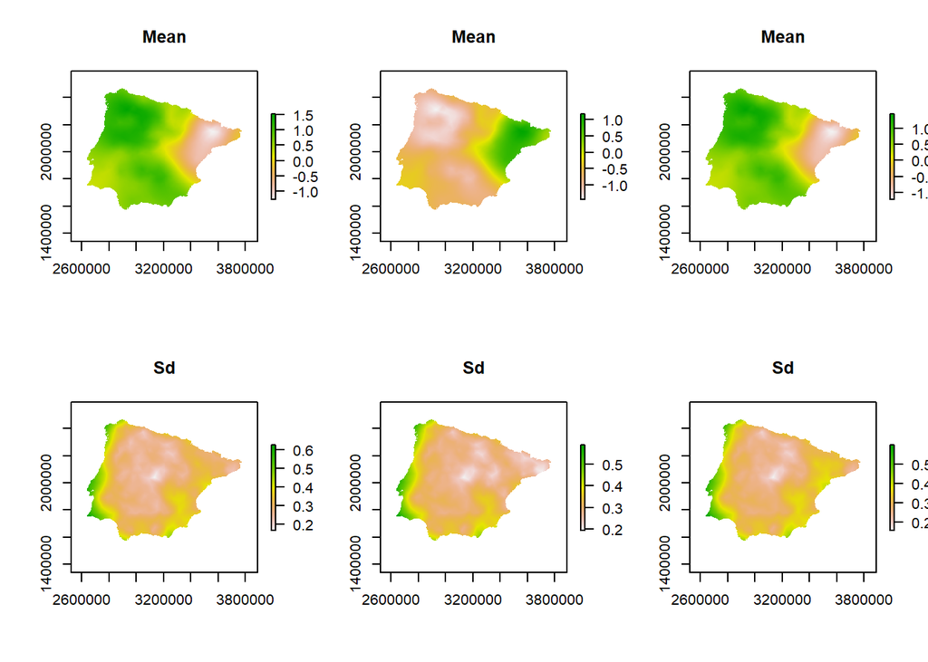

```r
par(mfrow = c(2,3))
plot(spatial_mean[[1]], main = "Mean")
plot(spatial_mean[[2]], main = "Mean")
plot(spatial_mean[[3]], main = "Mean")

plot(spatial_sd[[1]], main = "Sd")
plot(spatial_sd[[2]], main = "Sd")
plot(spatial_sd[[3]], main = "Sd")
```

### 4.6.4 Posterior distribution of the hyperparameters

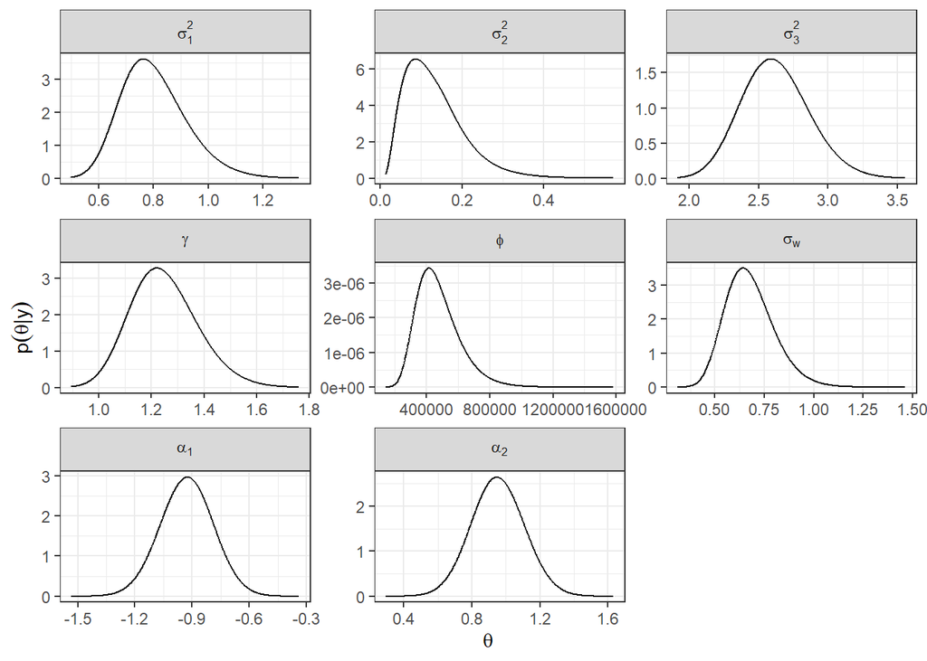

```r
prec <- list(sigma2.1 = model.typeVI$marginals.hyperpar$`Precision for the Gaussian observations`,
             sigma2.2 = model.typeVI$marginals.hyperpar$`Precision for the Gaussian observations[2]`,
             sigma2.3 = model.typeVI$marginals.hyperpar$`Precision for the Gaussian observations[3]`,
             gamma = model.typeVI$marginals.hyper$`Precision for id.z`)

hyper <- lapply(1:length(prec),
                function(x){
                  inla.smarginal(inla.tmarginal(prec[[x]], fun = function(y)(1/y))) %>%
                    data.frame(.)
                })
names(hyper) <- names(prec)
hyper <- c(hyper,
           sigma.sp = list(inla.smarginal(model.typeVI$marginals.hyperpar[["Stdev for iset.alr1"]])),
           phi = list(inla.smarginal(model.typeVI$marginals.hyperpar[["Range for iset.alr1"]])),
           alpha1 = list(inla.smarginal(model.typeVI$marginals.hyperpar[["Beta for iset.alr2"]])),
          alpha2 = list(inla.smarginal(model.typeVI$marginals.hyperpar[["Beta for iset.alr3"]])))




hyper.df <- lapply(1:length(hyper),
                   function(x){
                     cbind(data.frame(hyper[[x]]), name1 = names(hyper)[x])
                   })  %>%
  do.call(rbind.data.frame, .)

hyper.df$name1 <- ordered(hyper.df$name1,
                          levels = c("sigma2.1", "sigma2.2", "sigma2.3",
                                     "gamma", "phi", "sigma.sp", "alpha1", "alpha2"))

hyper.df$name1 <- ordered(hyper.df$name1,
                          levels = c("sigma2.1", "sigma2.2", "sigma2.3", "gamma", "phi", "sigma.sp", "alpha1", "alpha2"),
                          labels = c("sigma[1]^2", "sigma[2]^2", "sigma[3]^2", "gamma", "phi", "sigma[w]", "alpha[1]", "alpha[2]"))

p.hyper <- ggplot(hyper.df) +
  geom_line(aes(x = x, y = y)) +
  facet_wrap(~ name1, scales = "free",              labeller = label_parsed) +
  theme_bw() +
  xlab(expression(theta)) +
  ylab(expression(p(theta*'|'*y)))

print(p.hyper)
```

## 4.7 Type VII

Share the same parameters for fixed effects, and different realisations of the spatial effect for each linear predictor

### 4.7.1 Fitting the model

```r
formula.typeVII <- resp ~ -1 +
  intercept +
  sc_bio1 +
  sc_bio12 +
  f(i,
    model = spde,
    replicate = i.repl) +
  f(id.z,
    model = "iid",
    hyper = list(prec = list(prior = "pc.prec",
                             param = c(1, 0.01))), constr = TRUE)

model.typeVII <- inla(formula.typeVII,
                   family         = rep("gaussian", k - 1),
                   data           = inla.stack.data(stk.est),
                   control.compute = list(config = TRUE,
                                          dic  = TRUE,
                                          waic = TRUE,
                                          cpo  = TRUE),
                   control.predictor = list(A = inla.stack.A(stk.est),
                                            compute = TRUE),
                   control.family = list_prior,
                   verbose = FALSE)
```

### 4.7.2 Posterior distribution of the fixed effects

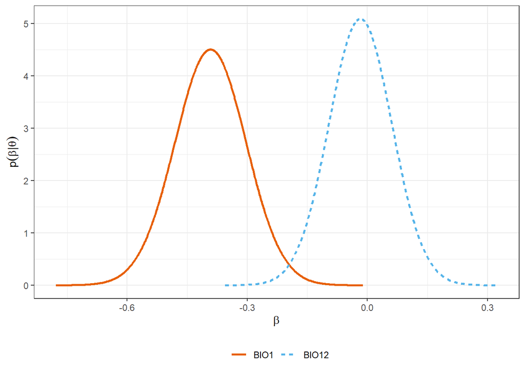

```r
data_fixed <- rbind(#data.frame(inla.smarginal(model.typeI$marginals.fixed$intercept), var = "Intercept"),
                    data.frame(inla.smarginal(model.typeVII$marginals.fixed$sc_bio1), var = "BIO1"),
                    data.frame(inla.smarginal(model.typeVII$marginals.fixed$sc_bio12), var = "BIO12"))

p_fixed <- ggplot() +
  geom_line(data = data_fixed, aes(x = x, y = y, col = var, linetype = var), size = 0.9) +
  #ggtitle("Effect of the covariate bio12") +
  theme_bw() +
  scale_color_manual(values=c("#E75F00", "#56B4E9"))+
  theme(legend.position = "bottom") +
  xlab(expression(beta)) +
  ylab(expression(p(beta *'|'* theta))) +
  theme(legend.title = element_blank())

p_fixed
```

### 4.7.3 Posterior distribution for the spatial effect

```r
raster_predict <- INLAcomp::raster_predict

spatial_mean <- raster_spatial_effect(spatial = model.typeVII$summary.random[['i']][['mean']],
                                      boundary = raster_predict)


spatial_sd <- raster_spatial_effect(spatial = model.typeVII$summary.random[['i']]$sd,
                                    boundary = raster_predict)
```

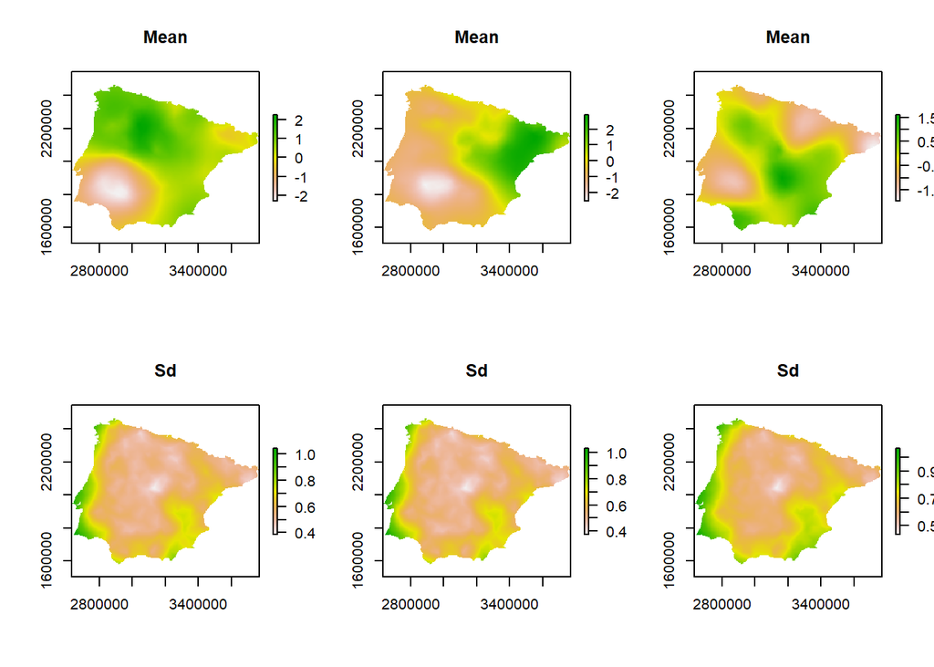

```r
par(mfrow = c(2,3))
plot(spatial_mean[[1]], main = "Mean")
plot(spatial_mean[[2]], main = "Mean")
plot(spatial_mean[[3]], main = "Mean")

plot(spatial_sd[[1]], main = "Sd")
plot(spatial_sd[[2]], main = "Sd")
plot(spatial_sd[[3]], main = "Sd")
```

### 4.7.4 Posterior distribution of the hyperparameters

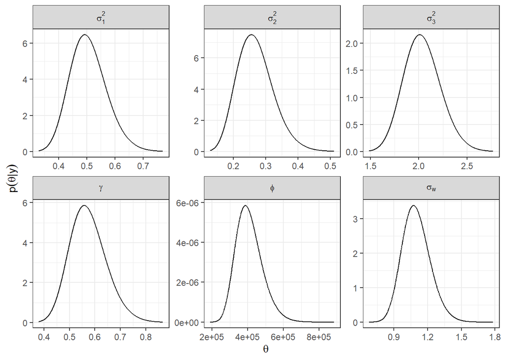

```r
### ------- 7.1.4. Posterior distributions of the hyperparameters --- ####
prec <- list(sigma2.1 = model.typeVII$marginals.hyperpar$`Precision for the Gaussian observations`,
             sigma2.2 = model.typeVII$marginals.hyperpar$`Precision for the Gaussian observations[2]`,
             sigma2.3 = model.typeVII$marginals.hyperpar$`Precision for the Gaussian observations[3]`,
             gamma = model.typeVII$marginals.hyper$`Precision for id.z`)

hyper <- lapply(1:length(prec),
                function(x){
                  inla.smarginal(inla.tmarginal(prec[[x]], fun = function(y)(1/y))) %>%
                    data.frame(.)
                })
names(hyper) <- names(prec)
hyper <- c(hyper,
           sigma.sp = list(inla.smarginal(model.typeVII$marginals.hyperpar[["Stdev for i"]])),
           phi = list(inla.smarginal(model.typeVII$marginals.hyperpar[["Range for i"]])))
hyper.df <- lapply(1:length(hyper),
                   function(x){
                     cbind(data.frame(hyper[[x]]), name1 = names(hyper)[x])
                   })  %>%
  do.call(rbind.data.frame, .)

hyper.df$name1 <- ordered(hyper.df$name1,
                          levels = c("sigma2.1", "sigma2.2", "sigma2.3",
                                     "gamma", "phi", "sigma.sp"))
hyper.df$name1 <- ordered(hyper.df$name1,
                          levels = c("sigma2.1", "sigma2.2", "sigma2.3", "gamma", "phi", "sigma.sp"),
                          labels = c("sigma[1]^2", "sigma[2]^2", "sigma[3]^2", "gamma", "phi", "sigma[w]"))

p.hyper <- ggplot(hyper.df) +
  geom_line(aes(x = x, y = y)) +
  facet_wrap(~ name1, scales = "free",              labeller = label_parsed) +
  theme_bw() +
  xlab(expression(theta)) +
  ylab(expression(p(theta*'|'*y)))

print(p.hyper)
```

## 4.8 Type VIII

Have different parameters for fixed effects, and different realisations of the spatial effect for each linear predictor

### 4.8.1 Fitting the model

```r
list_prior <- rep(list(list(prior = "pc.prec", param = c(1, 0.01))), k-1)

formula.typeVIII <- resp ~ -1 +
  f(id.intercept, intercept,
    model   = "iid",
    initial = log(1/1000),
    fixed   = TRUE) +
  f(id.sc_bio1, sc_bio1, #BIO1
    model   = "iid",
    initial = log(1/1000),
    fixed   = TRUE) +
  f(id.sc_bio12, sc_bio12, #bio12
    model   = "iid",
    initial = log(1/1000),
    fixed   = TRUE) +
  f(i,
    model = spde,
    replicate = i.repl) +
  f(id.z,
    model = "iid",
    hyper = list(prec = list(prior = "pc.prec",
                             param = c(1, 0.01))), constr = TRUE)

model.typeVIII <- inla(formula.typeVIII,
                   family         = rep("gaussian", k - 1),
                   data           = inla.stack.data(stk.est),
                   control.compute = list(config = TRUE,
                                          dic  = TRUE,
                                          waic = TRUE,
                                          cpo  = TRUE),
                   control.predictor = list(A = inla.stack.A(stk.est),
                                            compute = TRUE),
                   control.family = list_prior,
                   verbose = FALSE)
```

### 4.8.2 Posterior distribution of the fixed effects

```r
  ### ----- 7.1. Posterior distributions of fixed effects and hyperpars --- ####
### ------- 7.1.1. Fixed effects --- ####
##Bio12
data_fixed <- rbind(data.frame(inla.smarginal(model.typeVIII$marginals.random$id.sc_bio1$index.1), alr = "alr.gc1",
                               var = "BIO1"),
                    data.frame(inla.smarginal(model.typeVIII$marginals.random$id.sc_bio1$index.2), alr = "alr.gc2",
                               var = "BIO1"),
                    data.frame(inla.smarginal(model.typeVIII$marginals.random$id.sc_bio1$index.3), alr = "alr.gc3",
                               var = "BIO1"),
                    data.frame(inla.smarginal(model.typeVIII$marginals.random$id.sc_bio12$index.1), alr = "alr.gc1",
                               var = "BIO12"),
                    data.frame(inla.smarginal(model.typeVIII$marginals.random$id.sc_bio12$index.2), alr = "alr.gc2",
                               var = "BIO12"),
                    data.frame(inla.smarginal(model.typeVIII$marginals.random$id.sc_bio12$index.3), alr = "alr.gc3",
                               var = "BIO12"))
p_fixed <- ggplot() +
  geom_line(data = data_fixed, aes(x = x, y = y, col = var, linetype = var), size = 0.9) +
  #ggtitle("Effect of the covariate bio12") +
  theme_bw() +
  scale_color_manual(values=c("#E75F00", "#56B4E9"))+
  theme(legend.position = "bottom") +
  facet_wrap(~alr, nrow = 1) +
  xlab(expression(beta^(d))) +
  ylab(expression(p(beta^(d) *'|'* theta))) +
  theme(legend.title = element_blank())


inla.pmarginal(0, model.typeVIII$marginals.random$id.sc_bio1$index.1)
```

```
#> [1] 0.9748308
```

```r
inla.pmarginal(0, model.typeVIII$marginals.random$id.sc_bio1$index.2)
```

```
#> [1] 0.9999273
```

```r
inla.pmarginal(0, model.typeVIII$marginals.random$id.sc_bio1$index.3)
```

```
#> [1] 1
```

```r
inla.pmarginal(0, model.typeVIII$marginals.random$id.sc_bio12$index.1)
```

```
#> [1] 0.7215547
```

```r
inla.pmarginal(0, model.typeVIII$marginals.random$id.sc_bio12$index.2)
```

```
#> [1] 0.4081298
```

```r
inla.pmarginal(0, model.typeVIII$marginals.random$id.sc_bio12$index.3)
```

```
#> [1] 0.4778606
```

```r
1- exp(model.typeVIII$summary.random$id.sc_bio1$mean)
```

```
#> [1] 0.2011151 0.3265655 0.5020046
```

```r
1-exp(model.typeVIII$summary.random$id.sc_bio12$mean)
```

```
#> [1]  0.057817974 -0.022469438 -0.008330185
```

```r
pdf("fixed_arabidopsis.pdf", width = 9, height = 3)
p_fixed
dev.off()
```

### 4.8.3 Posterior distribution for the spatial effect

```r
raster_predict <- INLAcomp::raster_predict

spatial_mean <- raster_spatial_effect(spatial = model.typeVIII$summary.random[['i']][['mean']],
                                      boundary = raster_predict)


spatial_sd <- raster_spatial_effect(spatial = model.typeVIII$summary.random[['i']]$sd,
                                    boundary = raster_predict)
```

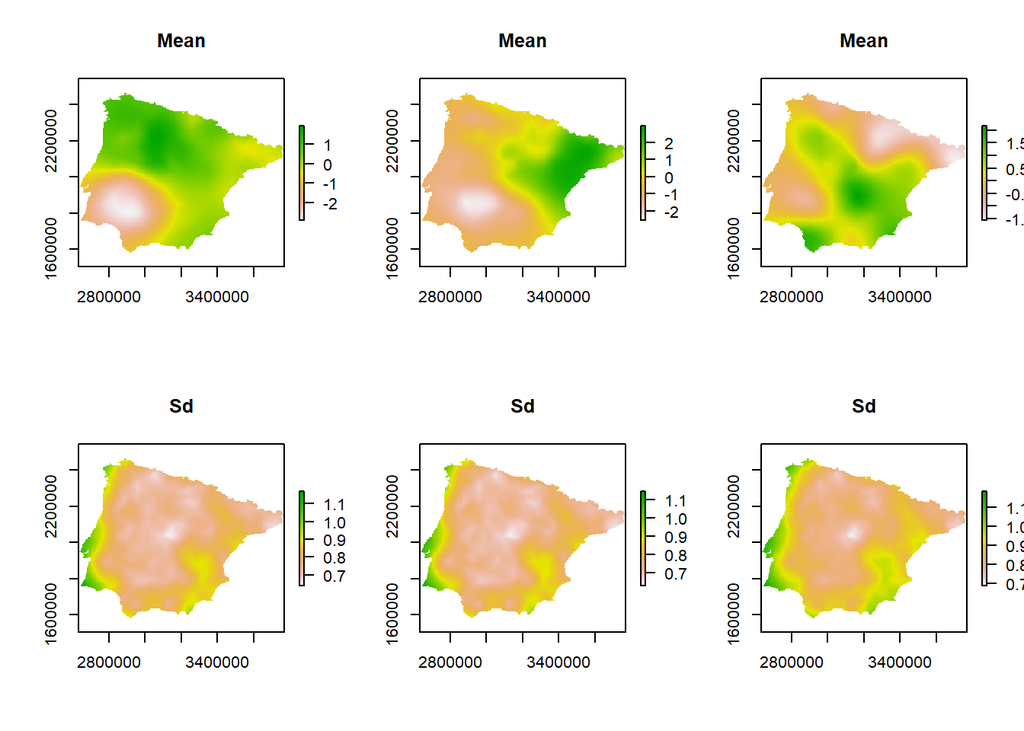

```r
par(mfrow = c(2,3))
plot(spatial_mean[[1]], main = "Mean")
plot(spatial_mean[[2]], main = "Mean")
plot(spatial_mean[[3]], main = "Mean")

plot(spatial_sd[[1]], main = "Sd")
plot(spatial_sd[[2]], main = "Sd")
plot(spatial_sd[[3]], main = "Sd")
```

### 4.8.4 Posterior distribution of the hyperparameters

```r
### ------- 7.1.4. Posterior distributions of the hyperparameters --- ####
prec <- list(sigma2.1 = model.typeVIII$marginals.hyperpar$`Precision for the Gaussian observations`,
             sigma2.2 = model.typeVIII$marginals.hyperpar$`Precision for the Gaussian observations[2]`,
             sigma2.3 = model.typeVIII$marginals.hyperpar$`Precision for the Gaussian observations[3]`,
             gamma = model.typeVIII$marginals.hyper$`Precision for id.z`)

hyper <- lapply(1:length(prec),
                function(x){
                  inla.smarginal(inla.tmarginal(prec[[x]], fun = function(y)(1/y))) %>%
                    data.frame(.)
                })
names(hyper) <- names(prec)
hyper <- c(hyper,
           sigma.sp = list(inla.smarginal(model.typeVIII$marginals.hyperpar[["Stdev for i"]])),
           phi = list(inla.smarginal(model.typeVIII$marginals.hyperpar[["Range for i"]])))
hyper.df <- lapply(1:length(hyper),
                   function(x){
                     cbind(data.frame(hyper[[x]]), name1 = names(hyper)[x])
                   })  %>%
  do.call(rbind.data.frame, .)

hyper.df$name1 <- ordered(hyper.df$name1,
                          levels = c("sigma2.1", "sigma2.2", "sigma2.3",
                                     "gamma", "phi", "sigma.sp"))
hyper.df$name1 <- ordered(hyper.df$name1,
                          levels = c("sigma2.1", "sigma2.2", "sigma2.3", "gamma", "phi", "sigma.sp"),
                          labels = c("sigma[1]^2", "sigma[2]^2", "sigma[3]^2", "gamma", "phi", "sigma[w]"))

p.hyper <- ggplot(hyper.df) +
  geom_line(aes(x = x, y = y)) +
  facet_wrap(~ name1, scales = "free",
             labeller = label_parsed) +
  theme_bw() +
  xlab(expression(theta)) +
  ylab(expression(p(theta*'|'*y)))

pdf("hyperpars.pdf", width = 7, height = 4)
print(p.hyper)
dev.off()
```

# 5 Comparing using DIC, WAIC and LCPO

In this tutorial, for the moment, we compute the DIC, WAIC and LCPO for all the models.

DIC and WAIC: We obtain the joint posterior distribution of the model using the `inla.posterior.sample` function. We use the functions `dic.mult` and `waic.mult` for computing the new DIC and WAIC.

CPO: We define friends in our dataset. We use the function `inla.group.cv` with the argument `num.level.sets = -1` for computing the CPO.

```r
model_list <- list(model.typeI,
               model.typeII,
               model.typeIII,
               model.typeIV,
               model.typeV,
               model.typeVI,
               model.typeVII,
               model.typeVIII)

names(model_list) <- paste0("type", c("I", "II", "III", "IV", "V", "VI", "VII", "VIII"))

## Computing measures of this model
measures <- lapply(model_list, function(mod1){
  xx <- inla.posterior.sample(1000, mod1, seed = inla.seed)
  inf <- mclapply(xx, INLAcomp::extract_lp_sigma)

  #DIC
  dic.mod1 <- INLAcomp::dic.mult(inf, y = data[, c(paste0("alr.gc", 1:(k-1)))])

  #WAIc
  waic.mod1 <- INLAcomp::waic.mult(inf, y = data[, c(paste0("alr.gc", 1:(k-1)))])

  #lIST FOR cpo
  friends_list <- 1:903 %>%
  lapply(., function(x){
    c(seq(x, 903, by = 301)[-1],
      rev(seq(x, 1, by = -301))) -> res
    res[order(res)]
  })

  a4 <- INLA::inla.group.cv(result = mod1,
                          num.level.sets = -1,
                          strategy = "posterior",
                          friends = friends_list)

  LCPO <- a4$cv %>% log(.) %>% mean(.) %>% -.

data.frame(DIC = dic.mod1, WAIC = waic.mod1, LCPO = LCPO)

})







measures <-  as.data.frame(do.call(rbind, measures))

measures
```

|  | DIC.e.dev | DIC.dev.e | DIC.p.eff | DIC.dic | WAIC.p.eff.waic | WAIC.waic | LCPO |
| --- | --- | --- | --- | --- | --- | --- | --- |
| typeI | 3347.317 | 3340.743 | 6.573284 | 3353.890 | 6.335917 | 3353.786 | 1.893806 |
| typeII | 3282.333 | 3270.105 | 12.227205 | 3294.560 | 13.037473 | 3295.630 | 1.867380 |
| typeIII | 3159.805 | 3117.363 | 42.442322 | 3202.248 | 43.041526 | 3208.579 | 1.786224 |
| typeIV | 3098.356 | 3050.683 | 47.673140 | 3146.029 | 49.907914 | 3154.323 | 1.757617 |
| typeV | 3009.270 | 2958.209 | 51.060956 | 3060.331 | 45.580355 | 3060.484 | 1.470104 |
| typeVI | 2950.093 | 2895.997 | 54.096756 | 3004.190 | 49.314094 | 3005.256 | 1.383999 |
| typeVII | 2641.082 | 2529.200 | 111.882337 | 2752.965 | 104.749066 | 2759.735 | 1.416203 |
| typeVIII | 2622.706 | 2504.315 | 118.390544 | 2741.096 | 111.960384 | 2750.654 | 1.401535 |